# Aedes aegypti in Brazil - fastStructure

###### 2.1.9.1.1 Create plot k8

Make plot

```r
# Extract ancestry coefficients
k9run1 <- read_delim(
  here("output", "populations", "faststructure", "luciano", "run01", "simple.8.meanQ"),
  delim = "  ", # Specify the delimiter if different from the default (comma)
  col_names = FALSE,
  show_col_types = FALSE
)

head(k9run1)
```

```
## # A tibble: 6 × 8
##         X1       X2       X3       X4       X5    X6       X7       X8
##      <dbl>    <dbl>    <dbl>    <dbl>    <dbl> <dbl>    <dbl>    <dbl>
## 1 0.000008 0.000008 0.154    0.000008 0.000008 0.846 0.000008 0.000008
## 2 0.000008 0.000008 0.000008 0.000008 0.000008 1.00  0.000008 0.000008
## 3 0.000008 0.000008 0.000008 0.000008 0.456    0.544 0.000008 0.000008
## 4 0.000008 0.000008 0.183    0.000008 0.000008 0.817 0.000008 0.000008
## 5 0.000008 0.000008 0.0508   0.000008 0.000008 0.875 0.0744   0.000008
## 6 0.000008 0.000008 0.000008 0.000008 0.000008 1.00  0.000008 0.000008
```

The fam file

```r
fam_file <- here(
  "output", "populations", "snps_sets", "brazil_2018.fam"
)

# Read the .fam file
fam_data <- read.table(fam_file,
                       header = FALSE,
                       col.names = c("FamilyID", "IndividualID", "PaternalID", "MaternalID", "Sex", "Phenotype"))

# View the first few rows
head(fam_data)
```

```
##   FamilyID IndividualID PaternalID MaternalID Sex Phenotype
## 1      PAR          236          0          0   0        -9
## 2      PAR          237          0          0   0        -9
## 3      PAR          238          0          0   0        -9
## 4      PAR          239          0          0   0        -9
## 5      PAR          240          0          0   0        -9
## 6      PAR          241          0          0   0        -9
```

Create ID column

```r
# Change column name
colnames(fam_data)[colnames(fam_data) == "IndividualID"] <- "ind"


# Change column name
colnames(fam_data)[colnames(fam_data) == "FamilyID"] <- "pop"

# Select ID
fam_data <- fam_data |>
  dplyr::select("ind", "pop")

# View the first few rows
head(fam_data)
```

```
##   ind pop
## 1 236 PAR
## 2 237 PAR
## 3 238 PAR
## 4 239 PAR
## 5 240 PAR
## 6 241 PAR
```

Add it to matrix

```r
k9run1 <- fam_data |>
  dplyr::select(ind, pop) |>
  bind_cols(k9run1)

head(k9run1)
```

```
##   ind pop    X1    X2       X3    X4       X5       X6       X7    X8
## 1 236 PAR 8e-06 8e-06 0.154195 8e-06 0.000008 0.845760 0.000008 8e-06
## 2 237 PAR 8e-06 8e-06 0.000008 8e-06 0.000008 0.999946 0.000008 8e-06
## 3 238 PAR 8e-06 8e-06 0.000008 8e-06 0.456020 0.543934 0.000008 8e-06
## 4 239 PAR 8e-06 8e-06 0.182946 8e-06 0.000008 0.817008 0.000008 8e-06
## 5 240 PAR 8e-06 8e-06 0.050812 8e-06 0.000008 0.874787 0.074363 8e-06
## 6 241 PAR 8e-06 8e-06 0.000008 8e-06 0.000008 0.999947 0.000008 8e-06
```

Rename the columns

```r
# Rename the columns starting from the third one
k9run1 <- k9run1 |>
  rename_with(~paste0("v", seq_along(.x)), .cols = -c(ind, pop))

# View the first few rows
head(k9run1)
```

```
##   ind pop    v1    v2       v3    v4       v5       v6       v7    v8
## 1 236 PAR 8e-06 8e-06 0.154195 8e-06 0.000008 0.845760 0.000008 8e-06
## 2 237 PAR 8e-06 8e-06 0.000008 8e-06 0.000008 0.999946 0.000008 8e-06
## 3 238 PAR 8e-06 8e-06 0.000008 8e-06 0.456020 0.543934 0.000008 8e-06
## 4 239 PAR 8e-06 8e-06 0.182946 8e-06 0.000008 0.817008 0.000008 8e-06
## 5 240 PAR 8e-06 8e-06 0.050812 8e-06 0.000008 0.874787 0.074363 8e-06
## 6 241 PAR 8e-06 8e-06 0.000008 8e-06 0.000008 0.999947 0.000008 8e-06
```

Import sample locations

```r
cities <- readRDS(here("output", "populations", "cities.rds"))
# cities <- cities |>
#   distinct(shortcode, .keep_all = TRUE)

head(cities)
```

```
## # A tibble: 6 × 7
##   pop   city         state latitude longitude region       biome
##   <chr> <chr>        <chr>    <dbl>     <dbl> <chr>        <chr>
## 1 BRA   Brasilia     DF      -15.8      -47.9 Central-West Cerrado
## 2 GOI   Goiania      GO      -16.7      -49.3 Central-West Cerrado
## 3 CAM   Campo Grande MS      -20.4      -54.6 Central-West Pantanal
## 4 CUI   Cuiaba       MT      -15.6      -56.1 Central-West Cerrado
## 5 RBR   Rio Branco   AC       -9.97     -67.8 North        Amazon
## 6 MAN   Manaus       AM       -3.13     -60.0 North        Amazon
```

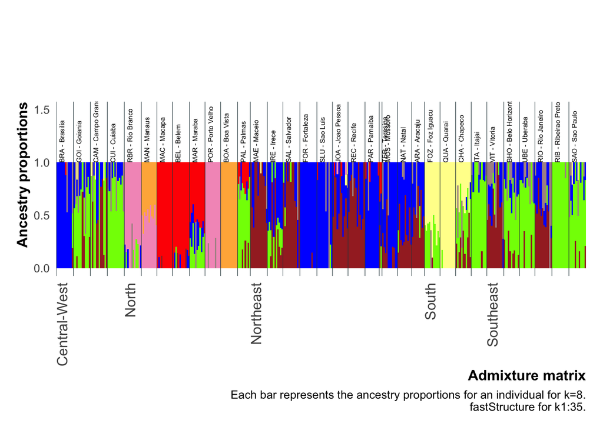

```r
source(
  here(
    "scripts", "analysis", "my_theme3.R"
  )
)

# Melt the data frame for plotting
Q_melted <- k9run1 |>
  pivot_longer(
    cols = -c(ind, pop),
    names_to = "variable",
    values_to = "value"
  )
# Join with sampling_loc to get sampling localities
Q_joined <- Q_melted |>
  left_join(cities, by = c("pop" = "pop"))

# # Create a combined variable for Region and Country
# Q_joined <- Q_joined |>
#   mutate(Region_Country = interaction(Region, Country, sep = "_"))

# Order the combined variable by Region and Country, then by individual
Q_ordered <- Q_joined |>
  arrange(region, state, city, ind) |>
  mutate(ind = factor(ind, levels = unique(ind)))  # Convert ind to a factor with levels in the desired order

# Add labels: country names for the first individual in each country, NA for all other individuals
Q_ordered <- Q_ordered |>
  group_by(region) |>
  mutate(label = ifelse(row_number() == 1, as.character(region), NA))

# Group by individual and variable, calculate mean ancestry proportions
Q_grouped <- Q_ordered |>
  group_by(ind, variable) |>
  summarise(value = mean(value), .groups = "drop")

# Create a data frame for borders
borders <-
  data.frame(region = unique(Q_ordered$region))

# Add the order of the last individual of each country to ensure correct placement of borders
borders$order <-
  sapply(borders$region, function(rc)
    max(which(Q_ordered$region == rc))) + 0.5  # Shift borders to the right edge of the bars

# Select only the first occurrence of each country in the ordered data
label_df <- Q_ordered |>
  filter(!is.na(label)) |>
  distinct(label, .keep_all = TRUE)

# Create a custom label function
label_func <- function(x) {
  labels <- rep("", length(x))
  labels[x %in% label_df$ind] <- label_df$label
  labels
}

# Calculate the position of lines
border_positions <- Q_ordered |>
  group_by(region) |>
  summarise(pos = max(as.numeric(ind)) + 0)

# Calculate the position of population labels and bars
pop_labels <- Q_ordered |>
  mutate(Name = paste(pop, city, sep = " - ")) |>
  group_by(pop) |>
  slice_head(n = 1) |>
  ungroup() |>
  dplyr::select(ind, city, biome, region, Name) |>
  mutate(pos = as.numeric(ind))  # calculate position of population labels

pop_labels_bars <- pop_labels |>
  mutate(pos = as.numeric(ind)  - .5)


# Calculate the position of lines
border_positions <- Q_ordered |>
  group_by(region) |>
  summarise(pos = max(as.numeric(ind)) - 1)


pop_labels_bars <- pop_labels |>
  mutate(pos = as.numeric(ind)  - .5)

# Function to filter and normalize data
normalize_data <- function(df, min_value) {
  df |>
    filter(value > min_value) |>
    group_by(ind) |>
    mutate(value = value / sum(value))
}

# Use the function
Q_grouped_filtered <- normalize_data(Q_grouped, 0.1)
#

color_palette <- c(
  "v1" = "#FFB347",
  "v2" = "#F49AC2",
  "v3" = "red",
  "v4" = "#FFFF99",
  "v5" = "#AE9393",
  "v6" = "blue",
  "v7" = "#7FFF00",
  "v8" = "brown"
)

# Generate all potential variable names
all_variables <- paste0("v", 1:8)

# Map each variable to a name
color_mapping <- data.frame(variable = all_variables,
                            color = names(color_palette))

# Merge with Q_grouped_filtered
Q_grouped_filtered <- merge(Q_grouped_filtered, color_mapping, by = "variable")

# Create the plot
ggplot(Q_grouped_filtered, aes(x = as.factor(ind), y = value, fill = color)) +
  geom_bar(stat = 'identity', width = 1) +
  geom_vline(
    data = pop_labels_bars,
    aes(xintercept = pos),
    color = "#2C444A",
    linewidth = .2
  ) +
  geom_text(
    data = pop_labels,
    aes(x = as.numeric(ind), y = 1, label = Name),
    vjust = 1.5,
    hjust = 0,
    size = 2,
    angle = 90,
    inherit.aes = FALSE
  ) +
  my_theme() +
  theme(
    axis.text.x = element_text(
      angle = 90,
      hjust = 1,
      size = 12
    ),
    legend.position = "none",
    plot.margin = unit(c(3, 0.5, 0.5, 0.5), "cm")
  ) +
  xlab("Admixture matrix") +
  ylab("Ancestry proportions") +
  labs(caption = "Each bar represents the ancestry proportions for an individual for k=8.\n fastStructure for k1:35.") +
  scale_x_discrete(labels = label_func) +
  scale_fill_manual(values = color_palette) +
  expand_limits(y = c(0, 1.5))
```

```r
# # save it
ggsave(
  here("output", "populations", "figures", "faststructure_simple_k8_luciano.pdf"),
  width  = 12,
  height = 6,
  units  = "in",
  device = cairo_pdf
)
```

###### 2.1.9.1.1 Create plot k7

Make plot

```r
# Extract ancestry coefficients
k9run1 <- read_delim(
  here("output", "populations", "faststructure", "luciano", "run01", "simple.7.meanQ"),
  delim = "  ", # Specify the delimiter if different from the default (comma)
  col_names = FALSE,
  show_col_types = FALSE
)

head(k9run1)
```

```
## # A tibble: 6 × 7
##         X1       X2    X3       X4    X5       X6       X7
##      <dbl>    <dbl> <dbl>    <dbl> <dbl>    <dbl>    <dbl>
## 1 0.000009 0.000009 0.396 0.0530   0.551 0.000009 0.000009
## 2 0.000009 0.000009 0.279 0.000009 0.721 0.000009 0.000009
## 3 0.000009 0.518    0.212 0.000009 0.269 0.000009 0.000009
## 4 0.000009 0.000009 0.492 0.000009 0.508 0.000009 0.000009
## 5 0.000009 0.000009 0.320 0.100    0.580 0.000009 0.000009
## 6 0.000009 0.000009 0.228 0.000009 0.772 0.000009 0.000009
```

The fam file

```r
fam_file <- here(
  "output", "populations", "snps_sets", "brazil_2018.fam"
)

# Read the .fam file
fam_data <- read.table(fam_file,
                       header = FALSE,
                       col.names = c("FamilyID", "IndividualID", "PaternalID", "MaternalID", "Sex", "Phenotype"))

# View the first few rows
head(fam_data)
```

```
##   FamilyID IndividualID PaternalID MaternalID Sex Phenotype
## 1      PAR          236          0          0   0        -9
## 2      PAR          237          0          0   0        -9
## 3      PAR          238          0          0   0        -9
## 4      PAR          239          0          0   0        -9
## 5      PAR          240          0          0   0        -9
## 6      PAR          241          0          0   0        -9
```

Create ID column

```r
# Change column name
colnames(fam_data)[colnames(fam_data) == "IndividualID"] <- "ind"


# Change column name
colnames(fam_data)[colnames(fam_data) == "FamilyID"] <- "pop"

# Select ID
fam_data <- fam_data |>
  dplyr::select("ind", "pop")

# View the first few rows
head(fam_data)
```

```
##   ind pop
## 1 236 PAR
## 2 237 PAR
## 3 238 PAR
## 4 239 PAR
## 5 240 PAR
## 6 241 PAR
```

Add it to matrix

```r
k9run1 <- fam_data |>
  dplyr::select(ind, pop) |>
  bind_cols(k9run1)

head(k9run1)
```

```
##   ind pop    X1       X2       X3       X4       X5    X6    X7
## 1 236 PAR 9e-06 0.000009 0.396138 0.052981 0.550847 9e-06 9e-06
## 2 237 PAR 9e-06 0.000009 0.278927 0.000009 0.721028 9e-06 9e-06
## 3 238 PAR 9e-06 0.518217 0.212306 0.000009 0.269442 9e-06 9e-06
## 4 239 PAR 9e-06 0.000009 0.491528 0.000009 0.508428 9e-06 9e-06
## 5 240 PAR 9e-06 0.000009 0.320009 0.099989 0.579967 9e-06 9e-06
## 6 241 PAR 9e-06 0.000009 0.227950 0.000009 0.772006 9e-06 9e-06
```

Rename the columns

```r
# Rename the columns starting from the third one
k9run1 <- k9run1 |>
  rename_with(~paste0("v", seq_along(.x)), .cols = -c(ind, pop))

# View the first few rows
head(k9run1)
```

```
##   ind pop    v1       v2       v3       v4       v5    v6    v7
## 1 236 PAR 9e-06 0.000009 0.396138 0.052981 0.550847 9e-06 9e-06
## 2 237 PAR 9e-06 0.000009 0.278927 0.000009 0.721028 9e-06 9e-06
## 3 238 PAR 9e-06 0.518217 0.212306 0.000009 0.269442 9e-06 9e-06
## 4 239 PAR 9e-06 0.000009 0.491528 0.000009 0.508428 9e-06 9e-06
## 5 240 PAR 9e-06 0.000009 0.320009 0.099989 0.579967 9e-06 9e-06
## 6 241 PAR 9e-06 0.000009 0.227950 0.000009 0.772006 9e-06 9e-06
```

Import sample locations

```r
cities <- readRDS(here("output", "populations", "cities.rds"))
# cities <- cities |>
#   distinct(shortcode, .keep_all = TRUE)

head(cities)
```

```
## # A tibble: 6 × 7
##   pop   city         state latitude longitude region       biome
##   <chr> <chr>        <chr>    <dbl>     <dbl> <chr>        <chr>
## 1 BRA   Brasilia     DF      -15.8      -47.9 Central-West Cerrado
## 2 GOI   Goiania      GO      -16.7      -49.3 Central-West Cerrado
## 3 CAM   Campo Grande MS      -20.4      -54.6 Central-West Pantanal
## 4 CUI   Cuiaba       MT      -15.6      -56.1 Central-West Cerrado
## 5 RBR   Rio Branco   AC       -9.97     -67.8 North        Amazon
## 6 MAN   Manaus       AM       -3.13     -60.0 North        Amazon
```

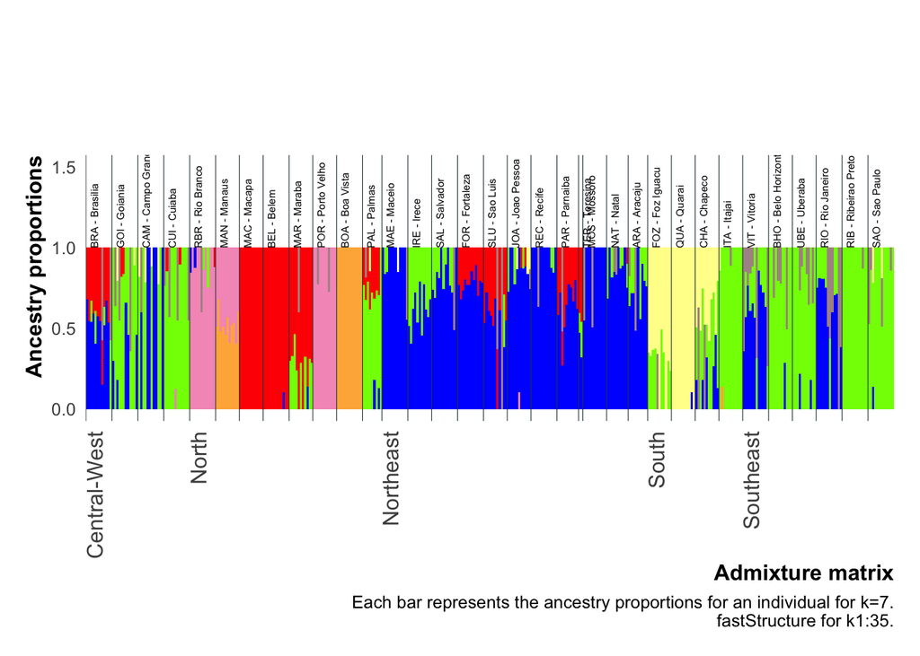

```r
source(
  here(
    "scripts", "analysis", "my_theme3.R"
  )
)

# Melt the data frame for plotting
Q_melted <- k9run1 |>
  pivot_longer(
    cols = -c(ind, pop),
    names_to = "variable",
    values_to = "value"
  )
# Join with sampling_loc to get sampling localities
Q_joined <- Q_melted |>
  left_join(cities, by = c("pop" = "pop"))

# # Create a combined variable for Region and Country
# Q_joined <- Q_joined |>
#   mutate(Region_Country = interaction(Region, Country, sep = "_"))

# Order the combined variable by Region and Country, then by individual
Q_ordered <- Q_joined |>
  arrange(region, state, city, ind) |>
  mutate(ind = factor(ind, levels = unique(ind)))  # Convert ind to a factor with levels in the desired order

# Add labels: country names for the first individual in each country, NA for all other individuals
Q_ordered <- Q_ordered |>
  group_by(region) |>
  mutate(label = ifelse(row_number() == 1, as.character(region), NA))

# Group by individual and variable, calculate mean ancestry proportions
Q_grouped <- Q_ordered |>
  group_by(ind, variable) |>
  summarise(value = mean(value), .groups = "drop")

# Create a data frame for borders
borders <-
  data.frame(region = unique(Q_ordered$region))

# Add the order of the last individual of each country to ensure correct placement of borders
borders$order <-
  sapply(borders$region, function(rc)
    max(which(Q_ordered$region == rc))) + 0.5  # Shift borders to the right edge of the bars

# Select only the first occurrence of each country in the ordered data
label_df <- Q_ordered |>
  filter(!is.na(label)) |>
  distinct(label, .keep_all = TRUE)

# Create a custom label function
label_func <- function(x) {
  labels <- rep("", length(x))
  labels[x %in% label_df$ind] <- label_df$label
  labels
}

# Calculate the position of lines
border_positions <- Q_ordered |>
  group_by(region) |>
  summarise(pos = max(as.numeric(ind)) + 0)

# Calculate the position of population labels and bars
pop_labels <- Q_ordered |>
  mutate(Name = paste(pop, city, sep = " - ")) |>
  group_by(pop) |>
  slice_head(n = 1) |>
  ungroup() |>
  dplyr::select(ind, city, biome, region, Name) |>
  mutate(pos = as.numeric(ind))  # calculate position of population labels

pop_labels_bars <- pop_labels |>
  mutate(pos = as.numeric(ind)  - .5)


# Calculate the position of lines
border_positions <- Q_ordered |>
  group_by(region) |>
  summarise(pos = max(as.numeric(ind)) - 1)


pop_labels_bars <- pop_labels |>
  mutate(pos = as.numeric(ind)  - .5)

# Function to filter and normalize data
normalize_data <- function(df, min_value) {
  df |>
    filter(value > min_value) |>
    group_by(ind) |>
    mutate(value = value / sum(value))
}

# Use the function
Q_grouped_filtered <- normalize_data(Q_grouped, 0.1)
#

color_palette <- c(
  "v1" = "#FFFF99",
  "v2" = "#AE9393",
  "v3" = "red",
  "v4" = "#7FFF00",
  "v5" = "blue",
  "v6" = "#F49AC2",
  "v7" = "#FFB347",
  "v8" = "brown"
)

# Generate all potential variable names
all_variables <- paste0("v", 1:8)

# Map each variable to a name
color_mapping <- data.frame(variable = all_variables,
                            color = names(color_palette))

# Merge with Q_grouped_filtered
Q_grouped_filtered <- merge(Q_grouped_filtered, color_mapping, by = "variable")

# Create the plot
ggplot(Q_grouped_filtered, aes(x = as.factor(ind), y = value, fill = color)) +
  geom_bar(stat = 'identity', width = 1) +
  geom_vline(
    data = pop_labels_bars,
    aes(xintercept = pos),
    color = "#2C444A",
    linewidth = .2
  ) +
  geom_text(
    data = pop_labels,
    aes(x = as.numeric(ind), y = 1, label = Name),
    vjust = 1.5,
    hjust = 0,
    size = 2,
    angle = 90,
    inherit.aes = FALSE
  ) +
  my_theme() +
  theme(
    axis.text.x = element_text(
      angle = 90,
      hjust = 1,
      size = 12
    ),
    legend.position = "none",
    plot.margin = unit(c(3, 0.5, 0.5, 0.5), "cm")
  ) +
  xlab("Admixture matrix") +
  ylab("Ancestry proportions") +
  labs(caption = "Each bar represents the ancestry proportions for an individual for k=7.\n fastStructure for k1:35.") +
  scale_x_discrete(labels = label_func) +
  scale_fill_manual(values = color_palette) +
  expand_limits(y = c(0, 1.5))
```

```r
# # save it
ggsave(
  here("output", "populations", "figures", "faststructure_simple_k7_luciano.pdf"),
  width  = 12,
  height = 6,
  units  = "in",
  device = cairo_pdf
)
```

###### 2.1.9.1.1 Create plot k6

Make plot

```r
# Extract ancestry coefficients
k9run1 <- read_delim(
  here("output", "populations", "faststructure", "luciano", "run01", "simple.6.meanQ"),
  delim = "  ", # Specify the delimiter if different from the default (comma)
  col_names = FALSE,
  show_col_types = FALSE
)

head(k9run1)
```

```
## # A tibble: 6 × 6
##        X1      X2    X3    X4      X5      X6
##     <dbl>   <dbl> <dbl> <dbl>   <dbl>   <dbl>
## 1 0.00001 0.00001 0.551 0.387 0.00001 0.0613
## 2 0.00001 0.00001 0.694 0.260 0.00001 0.0456
## 3 0.00001 0.505   0.304 0.191 0.00001 0.00001
## 4 0.00001 0.00001 0.500 0.500 0.00001 0.00001
## 5 0.00001 0.00001 0.592 0.313 0.00001 0.0947
## 6 0.00001 0.00001 0.768 0.232 0.00001 0.00001
```

The fam file

```r
fam_file <- here(
  "output", "populations", "snps_sets", "brazil_2018.fam"
)

# Read the .fam file
fam_data <- read.table(fam_file,
                       header = FALSE,
                       col.names = c("FamilyID", "IndividualID", "PaternalID", "MaternalID", "Sex", "Phenotype"))

# View the first few rows
head(fam_data)
```

```
##   FamilyID IndividualID PaternalID MaternalID Sex Phenotype
## 1      PAR          236          0          0   0        -9
## 2      PAR          237          0          0   0        -9
## 3      PAR          238          0          0   0        -9
## 4      PAR          239          0          0   0        -9
## 5      PAR          240          0          0   0        -9
## 6      PAR          241          0          0   0        -9
```

Create ID column

```r
# Change column name
colnames(fam_data)[colnames(fam_data) == "IndividualID"] <- "ind"


# Change column name
colnames(fam_data)[colnames(fam_data) == "FamilyID"] <- "pop"

# Select ID
fam_data <- fam_data |>
  dplyr::select("ind", "pop")

# View the first few rows
head(fam_data)
```

```
##   ind pop
## 1 236 PAR
## 2 237 PAR
## 3 238 PAR
## 4 239 PAR
## 5 240 PAR
## 6 241 PAR
```

Add it to matrix

```r
k9run1 <- fam_data |>
  dplyr::select(ind, pop) |>
  bind_cols(k9run1)

head(k9run1)
```

```
##   ind pop    X1       X2       X3       X4    X5       X6
## 1 236 PAR 1e-05 0.000010 0.551402 0.387283 1e-05 0.061284
## 2 237 PAR 1e-05 0.000010 0.693990 0.260356 1e-05 0.045623
## 3 238 PAR 1e-05 0.504988 0.303642 0.191339 1e-05 0.000010
## 4 239 PAR 1e-05 0.000010 0.499967 0.499992 1e-05 0.000010
## 5 240 PAR 1e-05 0.000010 0.592426 0.312867 1e-05 0.094676
## 6 241 PAR 1e-05 0.000010 0.767546 0.232413 1e-05 0.000010
```

Rename the columns

```r
# Rename the columns starting from the third one
k9run1 <- k9run1 |>
  rename_with(~paste0("v", seq_along(.x)), .cols = -c(ind, pop))

# View the first few rows
head(k9run1)
```

```
##   ind pop    v1       v2       v3       v4    v5       v6
## 1 236 PAR 1e-05 0.000010 0.551402 0.387283 1e-05 0.061284
## 2 237 PAR 1e-05 0.000010 0.693990 0.260356 1e-05 0.045623
## 3 238 PAR 1e-05 0.504988 0.303642 0.191339 1e-05 0.000010
## 4 239 PAR 1e-05 0.000010 0.499967 0.499992 1e-05 0.000010
## 5 240 PAR 1e-05 0.000010 0.592426 0.312867 1e-05 0.094676
## 6 241 PAR 1e-05 0.000010 0.767546 0.232413 1e-05 0.000010
```

Import sample locations

```r
cities <- readRDS(here("output", "populations", "cities.rds"))
# cities <- cities |>
#   distinct(shortcode, .keep_all = TRUE)

head(cities)
```

```
## # A tibble: 6 × 7
##   pop   city         state latitude longitude region       biome
##   <chr> <chr>        <chr>    <dbl>     <dbl> <chr>        <chr>
## 1 BRA   Brasilia     DF      -15.8      -47.9 Central-West Cerrado
## 2 GOI   Goiania      GO      -16.7      -49.3 Central-West Cerrado
## 3 CAM   Campo Grande MS      -20.4      -54.6 Central-West Pantanal
## 4 CUI   Cuiaba       MT      -15.6      -56.1 Central-West Cerrado
## 5 RBR   Rio Branco   AC       -9.97     -67.8 North        Amazon
## 6 MAN   Manaus       AM       -3.13     -60.0 North        Amazon
```

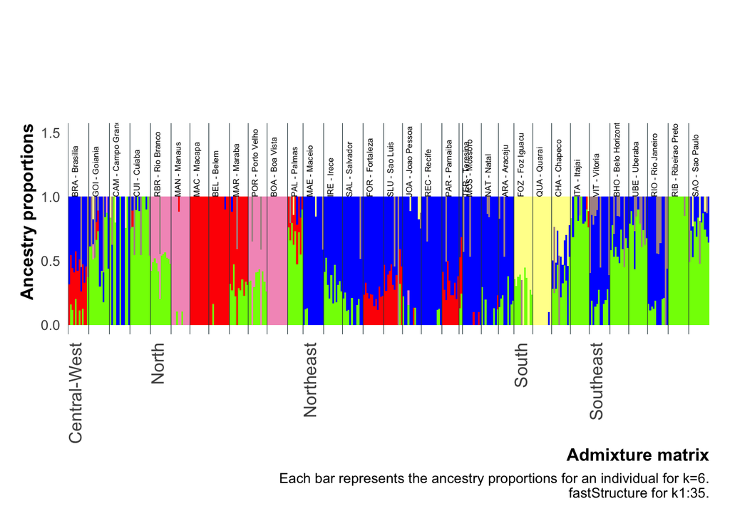

```r
source(
  here(
    "scripts", "analysis", "my_theme3.R"
  )
)

# Melt the data frame for plotting
Q_melted <- k9run1 |>
  pivot_longer(
    cols = -c(ind, pop),
    names_to = "variable",
    values_to = "value"
  )
# Join with sampling_loc to get sampling localities
Q_joined <- Q_melted |>
  left_join(cities, by = c("pop" = "pop"))

# # Create a combined variable for Region and Country
# Q_joined <- Q_joined |>
#   mutate(Region_Country = interaction(Region, Country, sep = "_"))

# Order the combined variable by Region and Country, then by individual
Q_ordered <- Q_joined |>
  arrange(region, state, city, ind) |>
  mutate(ind = factor(ind, levels = unique(ind)))  # Convert ind to a factor with levels in the desired order

# Add labels: country names for the first individual in each country, NA for all other individuals
Q_ordered <- Q_ordered |>
  group_by(region) |>
  mutate(label = ifelse(row_number() == 1, as.character(region), NA))

# Group by individual and variable, calculate mean ancestry proportions
Q_grouped <- Q_ordered |>
  group_by(ind, variable) |>
  summarise(value = mean(value), .groups = "drop")

# Create a data frame for borders
borders <-
  data.frame(region = unique(Q_ordered$region))

# Add the order of the last individual of each country to ensure correct placement of borders
borders$order <-
  sapply(borders$region, function(rc)
    max(which(Q_ordered$region == rc))) + 0.5  # Shift borders to the right edge of the bars

# Select only the first occurrence of each country in the ordered data
label_df <- Q_ordered |>
  filter(!is.na(label)) |>
  distinct(label, .keep_all = TRUE)

# Create a custom label function
label_func <- function(x) {
  labels <- rep("", length(x))
  labels[x %in% label_df$ind] <- label_df$label
  labels
}

# Calculate the position of lines
border_positions <- Q_ordered |>
  group_by(region) |>
  summarise(pos = max(as.numeric(ind)) + 0)

# Calculate the position of population labels and bars
pop_labels <- Q_ordered |>
  mutate(Name = paste(pop, city, sep = " - ")) |>
  group_by(pop) |>
  slice_head(n = 1) |>
  ungroup() |>
  dplyr::select(ind, city, biome, region, Name) |>
  mutate(pos = as.numeric(ind))  # calculate position of population labels

pop_labels_bars <- pop_labels |>
  mutate(pos = as.numeric(ind)  - .5)


# Calculate the position of lines
border_positions <- Q_ordered |>
  group_by(region) |>
  summarise(pos = max(as.numeric(ind)) - 1)


pop_labels_bars <- pop_labels |>
  mutate(pos = as.numeric(ind)  - .5)

# Function to filter and normalize data
normalize_data <- function(df, min_value) {
  df |>
    filter(value > min_value) |>
    group_by(ind) |>
    mutate(value = value / sum(value))
}

# Use the function
Q_grouped_filtered <- normalize_data(Q_grouped, 0.1)
#

color_palette <- c(
  "v1" = "#FFFF99",
  "v2" = "#AE9393",
  "v3" = "blue",
  "v4" = "red",
  "v5" = "#F49AC2",
  "v6" = "#7FFF00",
  "v7" = "#FFB347",
  "v8" = "brown"
)

# Generate all potential variable names
all_variables <- paste0("v", 1:8)

# Map each variable to a name
color_mapping <- data.frame(variable = all_variables,
                            color = names(color_palette))

# Merge with Q_grouped_filtered
Q_grouped_filtered <- merge(Q_grouped_filtered, color_mapping, by = "variable")

# Create the plot
ggplot(Q_grouped_filtered, aes(x = as.factor(ind), y = value, fill = color)) +
  geom_bar(stat = 'identity', width = 1) +
  geom_vline(
    data = pop_labels_bars,
    aes(xintercept = pos),
    color = "#2C444A",
    linewidth = .2
  ) +
  geom_text(
    data = pop_labels,
    aes(x = as.numeric(ind), y = 1, label = Name),
    vjust = 1.5,
    hjust = 0,
    size = 2,
    angle = 90,
    inherit.aes = FALSE
  ) +
  my_theme() +
  theme(
    axis.text.x = element_text(
      angle = 90,
      hjust = 1,
      size = 12
    ),
    legend.position = "none",
    plot.margin = unit(c(3, 0.5, 0.5, 0.5), "cm")
  ) +
  xlab("Admixture matrix") +
  ylab("Ancestry proportions") +
  labs(caption = "Each bar represents the ancestry proportions for an individual for k=6.\n fastStructure for k1:35.") +
  scale_x_discrete(labels = label_func) +
  scale_fill_manual(values = color_palette) +
  expand_limits(y = c(0, 1.5))
```

```r
# # save it
ggsave(
  here("output", "populations", "figures", "faststructure_simple_k6_luciano.pdf"),
  width  = 12,
  height = 6,
  units  = "in",
  device = cairo_pdf
)
```

###### 2.1.9.1.1 Create plot k5

Make plot

```r
# Extract ancestry coefficients
k9run1 <- read_delim(
  here("output", "populations", "faststructure", "luciano", "run01", "simple.5.meanQ"),
  delim = "  ", # Specify the delimiter if different from the default (comma)
  col_names = FALSE,
  show_col_types = FALSE
)

head(k9run1)
```

```
## # A tibble: 6 × 5
##         X1       X2    X3       X4    X5
##      <dbl>    <dbl> <dbl>    <dbl> <dbl>
## 1 0.0048   0.000012 0.559 0.000012 0.436
## 2 0.000013 0.000013 0.690 0.000013 0.310
## 3 0.445    0.000013 0.393 0.000013 0.162
## 4 0.000013 0.000013 0.485 0.000013 0.515
## 5 0.000013 0.000013 0.618 0.000013 0.382
## 6 0.000013 0.000013 0.744 0.000013 0.256
```

The fam file

```r
fam_file <- here(
  "output", "populations", "snps_sets", "brazil_2018.fam"
)

# Read the .fam file
fam_data <- read.table(fam_file,
                       header = FALSE,
                       col.names = c("FamilyID", "IndividualID", "PaternalID", "MaternalID", "Sex", "Phenotype"))

# View the first few rows
head(fam_data)
```

```
##   FamilyID IndividualID PaternalID MaternalID Sex Phenotype
## 1      PAR          236          0          0   0        -9
## 2      PAR          237          0          0   0        -9
## 3      PAR          238          0          0   0        -9
## 4      PAR          239          0          0   0        -9
## 5      PAR          240          0          0   0        -9
## 6      PAR          241          0          0   0        -9
```

Create ID column

```r
# Change column name
colnames(fam_data)[colnames(fam_data) == "IndividualID"] <- "ind"


# Change column name
colnames(fam_data)[colnames(fam_data) == "FamilyID"] <- "pop"

# Select ID
fam_data <- fam_data |>
  dplyr::select("ind", "pop")

# View the first few rows
head(fam_data)
```

```
##   ind pop
## 1 236 PAR
## 2 237 PAR
## 3 238 PAR
## 4 239 PAR
## 5 240 PAR
## 6 241 PAR
```

Add it to matrix

```r
k9run1 <- fam_data |>
  dplyr::select(ind, pop) |>
  bind_cols(k9run1)

head(k9run1)
```

```
##   ind pop       X1      X2       X3      X4       X5
## 1 236 PAR 0.004800 1.2e-05 0.559241 1.2e-05 0.435934
## 2 237 PAR 0.000013 1.3e-05 0.690291 1.3e-05 0.309671
## 3 238 PAR 0.444752 1.3e-05 0.393238 1.3e-05 0.161985
## 4 239 PAR 0.000013 1.3e-05 0.485091 1.3e-05 0.514871
## 5 240 PAR 0.000013 1.3e-05 0.617889 1.3e-05 0.382073
## 6 241 PAR 0.000013 1.3e-05 0.743788 1.3e-05 0.256174
```

Rename the columns

```r
# Rename the columns starting from the third one
k9run1 <- k9run1 |>
  rename_with(~paste0("v", seq_along(.x)), .cols = -c(ind, pop))

# View the first few rows
head(k9run1)
```

```
##   ind pop       v1      v2       v3      v4       v5
## 1 236 PAR 0.004800 1.2e-05 0.559241 1.2e-05 0.435934
## 2 237 PAR 0.000013 1.3e-05 0.690291 1.3e-05 0.309671
## 3 238 PAR 0.444752 1.3e-05 0.393238 1.3e-05 0.161985
## 4 239 PAR 0.000013 1.3e-05 0.485091 1.3e-05 0.514871
## 5 240 PAR 0.000013 1.3e-05 0.617889 1.3e-05 0.382073
## 6 241 PAR 0.000013 1.3e-05 0.743788 1.3e-05 0.256174
```

Import sample locations

```r
cities <- readRDS(here("output", "populations", "cities.rds"))
# cities <- cities |>
#   distinct(shortcode, .keep_all = TRUE)

head(cities)
```

```
## # A tibble: 6 × 7
##   pop   city         state latitude longitude region       biome
##   <chr> <chr>        <chr>    <dbl>     <dbl> <chr>        <chr>
## 1 BRA   Brasilia     DF      -15.8      -47.9 Central-West Cerrado
## 2 GOI   Goiania      GO      -16.7      -49.3 Central-West Cerrado
## 3 CAM   Campo Grande MS      -20.4      -54.6 Central-West Pantanal
## 4 CUI   Cuiaba       MT      -15.6      -56.1 Central-West Cerrado
## 5 RBR   Rio Branco   AC       -9.97     -67.8 North        Amazon
## 6 MAN   Manaus       AM       -3.13     -60.0 North        Amazon
```

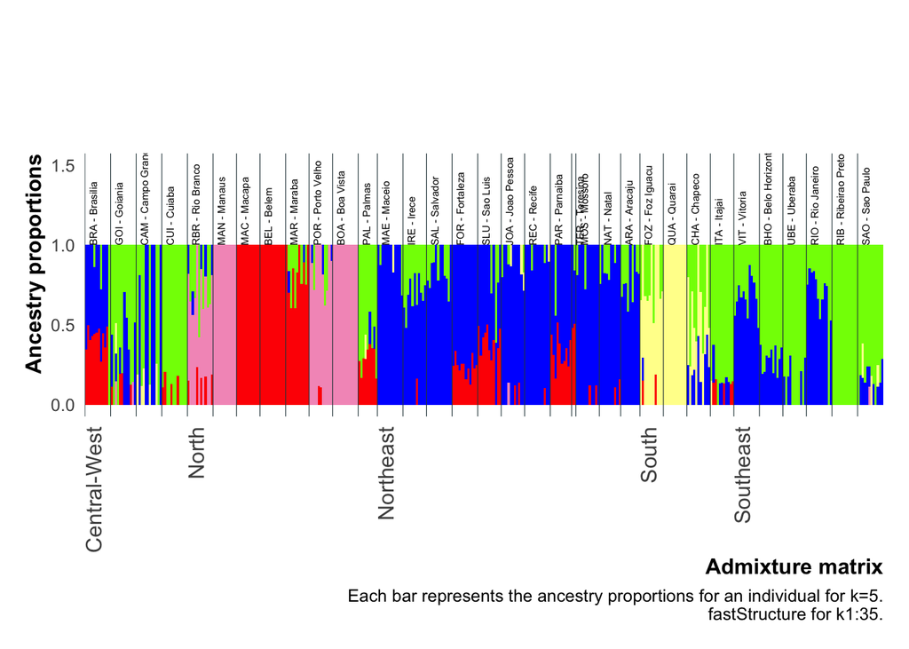

```r
source(
  here(
    "scripts", "analysis", "my_theme3.R"
  )
)

# Melt the data frame for plotting
Q_melted <- k9run1 |>
  pivot_longer(
    cols = -c(ind, pop),
    names_to = "variable",
    values_to = "value"
  )
# Join with sampling_loc to get sampling localities
Q_joined <- Q_melted |>
  left_join(cities, by = c("pop" = "pop"))

# # Create a combined variable for Region and Country
# Q_joined <- Q_joined |>
#   mutate(Region_Country = interaction(Region, Country, sep = "_"))

# Order the combined variable by Region and Country, then by individual
Q_ordered <- Q_joined |>
  arrange(region, state, city, ind) |>
  mutate(ind = factor(ind, levels = unique(ind)))  # Convert ind to a factor with levels in the desired order

# Add labels: country names for the first individual in each country, NA for all other individuals
Q_ordered <- Q_ordered |>
  group_by(region) |>
  mutate(label = ifelse(row_number() == 1, as.character(region), NA))

# Group by individual and variable, calculate mean ancestry proportions
Q_grouped <- Q_ordered |>
  group_by(ind, variable) |>
  summarise(value = mean(value), .groups = "drop")

# Create a data frame for borders
borders <-
  data.frame(region = unique(Q_ordered$region))

# Add the order of the last individual of each country to ensure correct placement of borders
borders$order <-
  sapply(borders$region, function(rc)
    max(which(Q_ordered$region == rc))) + 0.5  # Shift borders to the right edge of the bars

# Select only the first occurrence of each country in the ordered data
label_df <- Q_ordered |>
  filter(!is.na(label)) |>
  distinct(label, .keep_all = TRUE)

# Create a custom label function
label_func <- function(x) {
  labels <- rep("", length(x))
  labels[x %in% label_df$ind] <- label_df$label
  labels
}

# Calculate the position of lines
border_positions <- Q_ordered |>
  group_by(region) |>
  summarise(pos = max(as.numeric(ind)) + 0)

# Calculate the position of population labels and bars
pop_labels <- Q_ordered |>
  mutate(Name = paste(pop, city, sep = " - ")) |>
  group_by(pop) |>
  slice_head(n = 1) |>
  ungroup() |>
  dplyr::select(ind, city, biome, region, Name) |>
  mutate(pos = as.numeric(ind))  # calculate position of population labels

pop_labels_bars <- pop_labels |>
  mutate(pos = as.numeric(ind)  - .5)


# Calculate the position of lines
border_positions <- Q_ordered |>
  group_by(region) |>
  summarise(pos = max(as.numeric(ind)) - 1)


pop_labels_bars <- pop_labels |>
  mutate(pos = as.numeric(ind)  - .5)

# Function to filter and normalize data
normalize_data <- function(df, min_value) {
  df |>
    filter(value > min_value) |>
    group_by(ind) |>
    mutate(value = value / sum(value))
}

# Use the function
Q_grouped_filtered <- normalize_data(Q_grouped, 0.1)
#

color_palette <- c(
  "v1" = "#7FFF00",
  "v2" = "#FFFF99",
  "v3" = "blue",
  "v4" = "#F49AC2",
  "v5" = "red",
  "v6" = "#AE9393",
  "v7" = "#FFB347",
  "v8" = "brown"
)

# Generate all potential variable names
all_variables <- paste0("v", 1:8)

# Map each variable to a name
color_mapping <- data.frame(variable = all_variables,
                            color = names(color_palette))

# Merge with Q_grouped_filtered
Q_grouped_filtered <- merge(Q_grouped_filtered, color_mapping, by = "variable")

# Create the plot
ggplot(Q_grouped_filtered, aes(x = as.factor(ind), y = value, fill = color)) +
  geom_bar(stat = 'identity', width = 1) +
  geom_vline(
    data = pop_labels_bars,
    aes(xintercept = pos),
    color = "#2C444A",
    linewidth = .2
  ) +
  geom_text(
    data = pop_labels,
    aes(x = as.numeric(ind), y = 1, label = Name),
    vjust = 1.5,
    hjust = 0,
    size = 2,
    angle = 90,
    inherit.aes = FALSE
  ) +
  my_theme() +
  theme(
    axis.text.x = element_text(
      angle = 90,
      hjust = 1,
      size = 12
    ),
    legend.position = "none",
    plot.margin = unit(c(3, 0.5, 0.5, 0.5), "cm")
  ) +
  xlab("Admixture matrix") +
  ylab("Ancestry proportions") +
  labs(caption = "Each bar represents the ancestry proportions for an individual for k=5.\n fastStructure for k1:35.") +
  scale_x_discrete(labels = label_func) +
  scale_fill_manual(values = color_palette) +
  expand_limits(y = c(0, 1.5))
```

```r
# # save it
ggsave(
  here("output", "populations", "figures", "faststructure_simple_k5_luciano.pdf"),
  width  = 12,
  height = 6,
  units  = "in",
  device = cairo_pdf
)
```

### 2.2 Global set

Create a directory for each run

```bash
salloc --time=06:00:00 --nodes=1 --ntasks=1 --cpus-per-task=1 --mem-per-cpu=5120
cd /gpfs/ycga/project/caccone/lvc26/faststructure/aegypti/global
for i in $(seq -w 1 10)
do
  mkdir run$i
done
```

Now we can generate the full script for dsq (not showing here, because it has 2,000 lines).

#### 2.1.1 Simple prior

```bash
for k in $(seq 1 50); do
    for run in $(seq -w 1 10); do
        echo "cd /gpfs/ycga/project/caccone/lvc26/faststructure/aegypti/global; source /vast/palmer/apps/avx2/software/miniconda/23.3.1/etc/profile.d/conda.sh; module load miniconda/23.3.1; conda activate fastStructure; export PYTHONPATH=/home/lvc26/project/fastStructure; python -m structure -K $k --input=/gpfs/ycga/project/caccone/lvc26/faststructure/aegypti/global/global --output=/gpfs/ycga/project/caccone/lvc26/faststructure/aegypti/global/run$run/simple --prior=simple --full --cv=100 --tol=10e-9"
    done
done > dsq1.txt
```

#### 2.1.2 Logistic prior

I used 10 runs for the neutral set because it is around 9k SNPs. For other data sets we can do less runs because it takes too long.

```bash
for k in $(seq 1 30); do
    for run in $(seq -w 1 10); do
        echo "cd /gpfs/ycga/project/caccone/lvc26/faststructure/aegypti/brazil; source /vast/palmer/apps/avx2/software/miniconda/23.3.1/etc/profile.d/conda.sh;module load miniconda/23.3.1; conda activate fastStructure; export PYTHONPATH=/home/lvc26/project/fastStructure; python -m structure -K $k --input=/gpfs/ycga/project/caccone/lvc26/admixture/aegypti/brazil/brazil_2018 --output=/gpfs/ycga/project/caccone/lvc26/faststructure/aegypti/brazil/run$run/logistic --prior=logistic --full --cv=100 --tol=10e-9"
    done
done > dsq2.txt
```

Load dsq, and then create the batch file. Check the dsq –help

#### 2.1.3 Generate the dsq batch files

```r
module load dSQ/1.05
# make script, run, and do autopsy -> https://docs.ycrc.yale.edu/clusters-at-yale/job-scheduling/dsq/
# on Farnam the maximum job wall time is 30-00:00:00
##############################################
#                 Simple
##############################################

dsq \
--job-file dsq1.txt \
--mem-per-cpu 1g \
--cpus-per-task=1 \
--output /gpfs/ycga/project/caccone/lvc26/faststructure/aegypti/global/logs/faststruc_simple-%A_%3a-%N.txt \
-t 24:00:00 \
--mail-type END \
--partition=scavenge \
--job-name fastStr \
--output /dev/null \
--batch-file 1.simple.sh
# Then open it and add requeue
#nano 1.simple.sh
#SBATCH --requeue
# Since we use dsq autopsy to check the runs, I don't don't like the extra files.
#
##############################################
#                 Logistic
##############################################
dsq \
--job-file dsq2.txt \
--mem-per-cpu 1g \
--cpus-per-task=1 \
-t 24:00:00 \
--mail-type END \
--partition=scavenge \
--job-name fastStr_L \
--output /dev/null \
--batch-file 2.logistic.sh
```

Before we submit all jobs, it is a good practice to submit only one job of the array and see if it runs without problems.

If it runs without problems, we can submit all jobs.

```bash
sbatch 1.simple.sh
# Submitted batch job 7422953
sbatch 2.logistic.sh
# Submitted batch job
```

Check the jobs status.

```bash
# check status
dsqa -j 7424511 # PREEMPTED      46 TIMEOUT        14
dsqa -j
```

Run autopsy once it is done.

```bash
# simple, all completed
# logistic, some jobs PREEMPTED

dsqa -j 7424511 -f dsq1.txt -s PREEMPTED,TIMEOUT > rerun_jobs.txt; wc -l rerun_jobs.txt
# re submit the 60 jobs
dsq \
--job-file rerun_jobs.txt \
--mem-per-cpu 1g \
--cpus-per-task=1 \
--time 168:00:00 \
--mail-type END \
--partition=week \
--job-name fastStr_L2 \
--output /dev/null \
--batch-file 1.simple2.sh
#
# check status
dsqa -j 7540568 #
```

Run autopsy once it is done.

```bash
dsqa -j 6761666 -f dsq2.txt -s TIMEOUT > rerun_jobs.txt; wc -l rerun_jobs.txt
# re submit the 30 jobs
dsq \
--job-file rerun_jobs.txt \
--mem-per-cpu 1g \
--cpus-per-task=1 \
--time=168:00:00 \
--mail-type END \
--partition=week \
--job-name fastStr_L2 \
--output /dev/null \
--batch-file 2.logistic2.sh
#
# check status
dsqa -j 7327376 #
```

#### 2.1.4 Parse files from runs

Next, we will need to parse the results and make a plot. Our fist step is done on the cluster. We need to grab the Q matrices and the log files from our runs. We start wit the simple priors. I run fastStructure on the Farnam cluster. We first find the optimal number of Ks. Then we use pong to parse all 100 runs and generate one structure like plot. You can get pong here https://github.com/ramachandran-lab/pong. I installed pong on my base environment in my laptop. You can create a environment if you want, check their easy to follow instructions.

Data location

```bash
cd /gpfs/ycga/project/caccone/lvc26/faststructure/aegypti/global
```

#### 2.1.5 Choose k simple plot

First for our runs with simple prior.

```bash
salloc --time=06:00:00 --nodes=1 --ntasks=1 --cpus-per-task=1 --mem-per-cpu=5120
module load miniconda/23.3.1
conda activate fastStructure
export PYTHONPATH=/home/lvc26/project/fastStructure


# simple 10 runs
cat <(echo 'run likelihood structure') \
<(for i in /gpfs/ycga/project/caccone/lvc26/faststructure/aegypti/global/run*
do
    echo $i | sed 's@.*/@@' | sed 's/run/run /' ; python -m chooseK --input=$i/simple | grep 'likelihood' | awk '{print $6, $8}'; python -m chooseK --input=$i/simple | grep 'structure' |  awk '{print $6, $10}'
done | xargs -n6 | awk '{print $2, $4, $6}') > simple_prior_models.txt

# logistic 10 runs - not done
cat <(echo 'run likelihood structure') \
<(for i in /gpfs/ycga/project/caccone/lvc26/faststructure/aegypti/globa/run*
do
    echo $i | sed 's@.*/@@' | sed 's/run/run /' ; python -m chooseK --input=$i/logistic | grep 'likelihood' | awk '{print $6, $8}'; python -m chooseK --input=$i/logistic | grep 'structure' |  awk '{print $6, $10}'
done | xargs -n6 | awk '{print $2, $4, $6}') > logistic_prior_models.txt
```

Download the data

```bash
rsync -chavzP --stats lvc26@mccleary.ycrc.yale.edu:/gpfs/ycga/project/caccone/lvc26/faststructure/aegypti/global/*_prior_models.txt /Users/lucianocosme/Library/CloudStorage/Dropbox/popgen/brazil/aegypti/output/global_brazil/fastStructure
```

We can make a plot with the Ks. Let’s import the data in R.

```r
# function to import our choosek.py data
import_fastStructure <- function(file) {
  # import as a tibble and set columns as integers
  dat <- read_delim(
    file,
    col_names      = TRUE,
    show_col_types = FALSE,
    col_types      = "iii"
  )

  # get columns we need and make it long for plotting
  dat <- dat |>
    gather(
      structure, likelihood, -run
    )

  # rename the columns by index
  dat <- dat |>
    rename(
      run   = 1,
      model = 2,
      k     = 3
    )
  return(dat)
}
# we can save the function to source it later
dump(
  "import_fastStructure",
  here(
    "scripts", "analysis", "import_fastStructure.R"
  ),
  append = TRUE
)
```

Now we can use the function to import the data

```r
# we can use our function with here to import the data
choose_k_simple <-
  import_fastStructure(
  here(
    "output", "global_brazil","fastStructure","simple_prior_models.txt"
  )
)
```

Function to plot fastStructure choosek.py results

```r
# function to plot our choosek.py data
plot_fastStructure <- function(df) {
  df |>
    ggplot() +
    geom_line(
      aes(
        x              = run,
        y              = k,
        color          = model
      ),
      linewidth = 1
    ) +
    scale_colour_manual(
      "model",
      values = c(
        structure      = "#9d60ff",
        likelihood     = "#ffc08c"
      ),
      labels = c(
        "Maximizes \n Likelihood \n", "Explain \n Structure"
      )
    ) +
    labs(
      x                = "Run",
      y                = "K",
      title            = "fastStructure",
      caption          = "algorithm runs for choices of K ranging from 1 to 50"
    ) +
    hrbrthemes::theme_ipsum(
      base_family = "",
      axis_text_size = 12,
      axis_title_size = 14,
      plot_margin = margin(
        10, 10, 10, 10
      ),
      grid = TRUE,
      grid_col = "#fabbe2"
    ) +
    theme(
      panel.grid.major = element_line(
        linetype       = "dashed",
        linewidth      = 0.2
      ),
      panel.grid.minor = element_line(
        linetype       = "dashed",
        linewidth      = 0.2
      ),
      legend.text = element_text(
        size = 12
      ),
      legend.title = element_text(
        size           = 14,
        face           = "bold"
      ),
      legend.position = "right"
    )
}
# we can save the function to source it later
# dump(
#   "plot_fastStructure",
#   here(
#     "scripts", "analysis", "plot_fastStructure.R"
#   ),
#   append = TRUE
# )
```

Use our function to plot k values

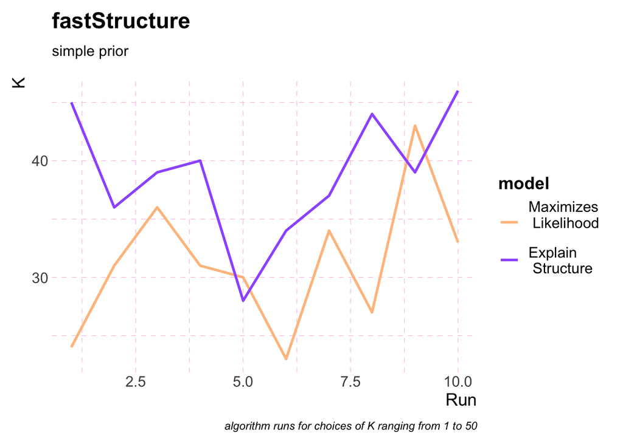

```r
plot_fastStructure(
  choose_k_simple
) +
  labs(
    subtitle = "simple prior"
  )
```

```r
# # save plot
ggsave(
  here(
    "output", "global_brazil", "faststructure", "fastStructure_simple_prior_k1_k50.pdf"
  ),
  width  = 8,
  height = 6,
  units  = "in"
)
```

```r
# Group by 'model' and 'k', and then summarise by counting the number of runs
# for each combination of 'model' and 'k'.
# Finally, filter to keep only the row with the maximum count for each 'model'.
most_common_k <- choose_k_simple |>
  group_by(model, k) |>
  summarise(n = n()) |>
  group_by(model) |>
  filter(n == max(n))
print(most_common_k)
```

```
## # A tibble: 2 × 3
## # Groups:   model [2]
##   model          k     n
##   <chr>      <int> <int>
## 1 likelihood    31     2
## 2 structure     39     2
```

k=31

Smallest k

```r
smallest_k_per_model <- choose_k_simple |>
  group_by(model) |>
  summarise(min_k = min(k), .groups = "drop")

print(smallest_k_per_model)
```

```
## # A tibble: 2 × 2
##   model      min_k
##   <chr>      <int>
## 1 likelihood    23
## 2 structure     28
```

Largest k

```r
largest_k_per_model <- choose_k_simple |>
  group_by(model) |>
  summarise(max_k = max(k), .groups = "drop")

print(largest_k_per_model)
```

```
## # A tibble: 2 × 2
##   model      max_k
##   <chr>      <int>
## 1 likelihood    43
## 2 structure     46
```

Since there is a lot of variation from run to run, we can plot the k=25 since we plotted it with LEA.

#### 2.1.9 pong

Download the data

```bash
# next we can download the files to our computer, run the command below in your computer, not in the cluster
rsync -chavzP --stats --include='*/' --include='*.meanQ' --exclude='*' lvc26@mccleary.ycrc.yale.edu:/gpfs/ycga/project/caccone/lvc26/faststructure/aegypti/global/* /Users/lucianocosme/Library/CloudStorage/Dropbox/popgen/brazil/aegypti/output/global_brazil/faststructure
```

##### 2.1.9.1 simple prior

Check the downloaded data

```bash
ls -1 output/populations/faststructure/luciano/run*/simple* | tail
```

Create filemap2.txt

```bash
# we will use only the first 10 runs to make the plot.
# loop to generate filemap2.txt with k values from 2 to 15. I use tab instead of space. We need that for pong.
for k in $(seq 2 25); do
    for run in $(seq -w 1 10); do
        echo "k$k""r$run $k faststructure/run$run/simple.$k.meanQ" | tr ' ' '\t'
    done
done > output/global_brazil/filemap2.txt;
head -n 5 output/global_brazil/filemap2.txt
```

```bash
wc -l output/populations/filemap2.txt
```

Create ind2pop

```bash
rm output/global_brazil/ind2pop.txt;
cat output/global_brazil/snps_sets/global.fam | awk '{print $1}' > output/global_brazil/ind2pop.txt;
head -n 5 output/global_brazil/ind2pop.txt
```

Run on the terminal and not on RStudio.

```bash
# on your computer to visualize the results
pong \
--filemap output/global_brazil/filemap2.txt \
--ind2pop output/global_brazil/ind2pop.txt  \
--dist_metric jaccard \
--sim_threshold 0.82 \
--greedy \
--force \
--output_dir output/global_brazil/sim_threshold_0.82 \
--verbose
```

The logs from pong

```r
# -------------------------------------------------------------------
#                             p o n g
#       by A. Behr, K. Liu, T. Devlin, G. Liu-Fang, and S. Ramachandran
#                        Version 1.5 (2021)
# -------------------------------------------------------------------
# -------------------------------------------------------------------
#
# Parsing input and generating cluster network graph
# Matching clusters within each K and finding representative runs
# For K=2, there is 1 mode across 10 runs.
# For K=3, there is 1 mode across 10 runs.
# For K=4, there is 1 mode across 10 runs.
# For K=5, there is 1 mode across 10 runs.
# For K=6, there is 1 mode across 10 runs.
# For K=7, there is 1 mode across 10 runs.
#
# Warning: pong could not find disjoint modes given similarity threshold.
# For K=8, there are 2 modes across 10 runs.
#
# Warning: pong could not find disjoint modes given similarity threshold.
# For K=9, there are 2 modes across 10 runs.
# For K=10, there is 1 mode across 10 runs.
# For K=11, there is 1 mode across 10 runs.
# For K=12, there is 1 mode across 10 runs.
# For K=13, there is 1 mode across 10 runs.
#
# Warning: pong could not find disjoint modes given similarity threshold.
# For K=14, there are 2 modes across 10 runs.
# For K=15, there is 1 mode across 10 runs.
# For K=16, there is 1 mode across 10 runs.
# For K=17, there is 1 mode across 10 runs.
#
# Warning: pong could not find disjoint modes given similarity threshold.
# For K=18, there are 2 modes across 10 runs.
#
# Warning: pong could not find disjoint modes given similarity threshold.
# For K=19, there are 2 modes across 10 runs.
#
# Warning: pong could not find disjoint modes given similarity threshold.
# For K=20, there are 2 modes across 10 runs.
#
# Warning: pong could not find disjoint modes given similarity threshold.
# For K=21, there are 3 modes across 10 runs.
#
# Warning: pong could not find disjoint modes given similarity threshold.
# For K=22, there are 3 modes across 10 runs.
#
# Warning: pong could not find disjoint modes given similarity threshold.
# For K=23, there are 3 modes across 10 runs.
#
# Warning: pong could not find disjoint modes given similarity threshold.
# For K=24, there are 5 modes across 10 runs.
#
# Warning: pong could not find disjoint modes given similarity threshold.
# For K=25, there are 5 modes across 10 runs.
# Matching clusters across K
# Finding best alignment for all runs within and across K
# match time: 76.81s
# align time: 8.68s
# total time: 88.78s
# -----------------------------------------------------------
# pong server is now running locally & listening on port 4000
# Open your web browser and navigate to http://localhost:4000 to see the visualization
```

We have 5 modes for k=25. However, 5 runs have the same mode. Runs: 2,3,4,6, anb 7

###### 2.1.9.1.1 Create plot k25

Make plot

```r
# Extract ancestry coefficients
k25run2 <- read_delim(
  here("output", "global_brazil", "faststructure", "run02", "simple.25.meanQ"),
  delim = "  ", # Specify the delimiter if different from the default (comma)
  col_names = FALSE,
  show_col_types = FALSE
)

head(k25run2)
```

```
## # A tibble: 6 × 25
##       X1    X2    X3    X4    X5    X6    X7    X8    X9   X10   X11   X12   X13
##    <dbl> <dbl> <dbl> <dbl> <dbl> <dbl> <dbl> <dbl> <dbl> <dbl> <dbl> <dbl> <dbl>
## 1   2e-6  2e-6  2e-6  2e-6  2e-6  2e-6  2e-6  2e-6  2e-6  2e-6  2e-6  2e-6  2e-6
## 2   2e-6  2e-6  2e-6  2e-6  2e-6  2e-6  2e-6  2e-6  2e-6  2e-6  2e-6  2e-6  2e-6
## 3   2e-6  2e-6  2e-6  2e-6  2e-6  2e-6  2e-6  2e-6  2e-6  2e-6  2e-6  2e-6  2e-6
## 4   2e-6  2e-6  2e-6  2e-6  2e-6  2e-6  2e-6  2e-6  2e-6  2e-6  2e-6  2e-6  2e-6
## 5   2e-6  2e-6  2e-6  2e-6  2e-6  2e-6  2e-6  2e-6  2e-6  2e-6  2e-6  2e-6  2e-6
## 6   2e-6  2e-6  2e-6  2e-6  2e-6  2e-6  2e-6  2e-6  2e-6  2e-6  2e-6  2e-6  2e-6
## # ℹ 12 more variables: X14 <dbl>, X15 <dbl>, X16 <dbl>, X17 <dbl>, X18 <dbl>,
## #   X19 <dbl>, X20 <dbl>, X21 <dbl>, X22 <dbl>, X23 <dbl>, X24 <dbl>, X25 <dbl>
```

The fam file

```r
fam_file <- here(
  "output", "global_brazil", "snps_sets", "global.fam"
)

# Read the .fam file
fam_data <- read.table(fam_file,
                       header = FALSE,
                       col.names = c("FamilyID", "IndividualID", "PaternalID", "MaternalID", "Sex", "Phenotype"))

# View the first few rows
head(fam_data)
```

```
##   FamilyID IndividualID PaternalID MaternalID Sex Phenotype
## 1     JOHA          393          0          0   0        -9
## 2     JOHA          394          0          0   0        -9
## 3     JOHA          395          0          0   0        -9
## 4     JOHA          396          0          0   0        -9
## 5     JOHA          397          0          0   0        -9
## 6     JOHA          398          0          0   0        -9
```

Create ID column

```r
# Change column name
colnames(fam_data)[colnames(fam_data) == "IndividualID"] <- "ind"


# Change column name
colnames(fam_data)[colnames(fam_data) == "FamilyID"] <- "pop"

# Select ID
fam_data <- fam_data |>
  dplyr::select("ind", "pop")

# View the first few rows
head(fam_data)
```

```
##   ind  pop
## 1 393 JOHA
## 2 394 JOHA
## 3 395 JOHA
## 4 396 JOHA
## 5 397 JOHA
## 6 398 JOHA
```

Add it to matrix

```r
k25run2 <- fam_data |>
  dplyr::select(ind, pop) |>
  bind_cols(k25run2)

head(k25run2)
```

```
##   ind  pop    X1    X2    X3    X4    X5    X6    X7    X8    X9   X10   X11
## 1 393 JOHA 2e-06 2e-06 2e-06 2e-06 2e-06 2e-06 2e-06 2e-06 2e-06 2e-06 2e-06
## 2 394 JOHA 2e-06 2e-06 2e-06 2e-06 2e-06 2e-06 2e-06 2e-06 2e-06 2e-06 2e-06
## 3 395 JOHA 2e-06 2e-06 2e-06 2e-06 2e-06 2e-06 2e-06 2e-06 2e-06 2e-06 2e-06
## 4 396 JOHA 2e-06 2e-06 2e-06 2e-06 2e-06 2e-06 2e-06 2e-06 2e-06 2e-06 2e-06
## 5 397 JOHA 2e-06 2e-06 2e-06 2e-06 2e-06 2e-06 2e-06 2e-06 2e-06 2e-06 2e-06
## 6 398 JOHA 2e-06 2e-06 2e-06 2e-06 2e-06 2e-06 2e-06 2e-06 2e-06 2e-06 2e-06
##     X12   X13   X14   X15   X16   X17   X18   X19   X20   X21      X22   X23
## 1 2e-06 2e-06 2e-06 2e-06 2e-06 2e-06 2e-06 2e-06 2e-06 2e-06 0.999944 2e-06
## 2 2e-06 2e-06 2e-06 2e-06 2e-06 2e-06 2e-06 2e-06 2e-06 2e-06 0.999944 2e-06
## 3 2e-06 2e-06 2e-06 2e-06 2e-06 2e-06 2e-06 2e-06 2e-06 2e-06 0.999944 2e-06
## 4 2e-06 2e-06 2e-06 2e-06 2e-06 2e-06 2e-06 2e-06 2e-06 2e-06 0.999944 2e-06
## 5 2e-06 2e-06 2e-06 2e-06 2e-06 2e-06 2e-06 2e-06 2e-06 2e-06 0.999944 2e-06
## 6 2e-06 2e-06 2e-06 2e-06 2e-06 2e-06 2e-06 2e-06 2e-06 2e-06 0.999944 2e-06
##     X24   X25
## 1 2e-06 2e-06
## 2 2e-06 2e-06
## 3 2e-06 2e-06
## 4 2e-06 2e-06
## 5 2e-06 2e-06
## 6 2e-06 2e-06
```

Rename the columns

```r
# Rename the columns starting from the third one
k25run2 <- k25run2 |>
  rename_with(~paste0("v", seq_along(.x)), .cols = -c(ind, pop))

# View the first few rows
head(k25run2)
```

```
##   ind  pop    v1    v2    v3    v4    v5    v6    v7    v8    v9   v10   v11
## 1 393 JOHA 2e-06 2e-06 2e-06 2e-06 2e-06 2e-06 2e-06 2e-06 2e-06 2e-06 2e-06
## 2 394 JOHA 2e-06 2e-06 2e-06 2e-06 2e-06 2e-06 2e-06 2e-06 2e-06 2e-06 2e-06
## 3 395 JOHA 2e-06 2e-06 2e-06 2e-06 2e-06 2e-06 2e-06 2e-06 2e-06 2e-06 2e-06
## 4 396 JOHA 2e-06 2e-06 2e-06 2e-06 2e-06 2e-06 2e-06 2e-06 2e-06 2e-06 2e-06
## 5 397 JOHA 2e-06 2e-06 2e-06 2e-06 2e-06 2e-06 2e-06 2e-06 2e-06 2e-06 2e-06
## 6 398 JOHA 2e-06 2e-06 2e-06 2e-06 2e-06 2e-06 2e-06 2e-06 2e-06 2e-06 2e-06
##     v12   v13   v14   v15   v16   v17   v18   v19   v20   v21      v22   v23
## 1 2e-06 2e-06 2e-06 2e-06 2e-06 2e-06 2e-06 2e-06 2e-06 2e-06 0.999944 2e-06
## 2 2e-06 2e-06 2e-06 2e-06 2e-06 2e-06 2e-06 2e-06 2e-06 2e-06 0.999944 2e-06
## 3 2e-06 2e-06 2e-06 2e-06 2e-06 2e-06 2e-06 2e-06 2e-06 2e-06 0.999944 2e-06
## 4 2e-06 2e-06 2e-06 2e-06 2e-06 2e-06 2e-06 2e-06 2e-06 2e-06 0.999944 2e-06
## 5 2e-06 2e-06 2e-06 2e-06 2e-06 2e-06 2e-06 2e-06 2e-06 2e-06 0.999944 2e-06
## 6 2e-06 2e-06 2e-06 2e-06 2e-06 2e-06 2e-06 2e-06 2e-06 2e-06 0.999944 2e-06
##     v24   v25
## 1 2e-06 2e-06
## 2 2e-06 2e-06
## 3 2e-06 2e-06
## 4 2e-06 2e-06
## 5 2e-06 2e-06
## 6 2e-06 2e-06
```

Import sample locations

```r
cities <- readRDS(here("output", "global_brazil", "cities_loc.rds"))
# cities <- cities |>
#   distinct(shortcode, .keep_all = TRUE)

head(cities)
```

```
##    pop         city    country    Continent          Region   Latitude
## 1 AMAC     Amacuzac     Mexico     Americas   North America  18.597414
## 2 CAIR       Cairns  Australia Asia Pacific         Oceania -16.817295
## 3 CALI         Cali   Colombia     Americas   South America   3.438936
## 4 CAGR Campo Grande     Brazil     Americas   South America -20.468821
## 5 CLOV       Clovis        USA     Americas   North America  36.827016
## 6 SIQU    Siquirres Costa Rica     Americas Central America   9.938477
##    Longitude
## 1  -99.37164
## 2  145.68578
## 3  -76.51557
## 4  -54.62936
## 5 -119.69176
## 6  -84.09530
```

Create colors

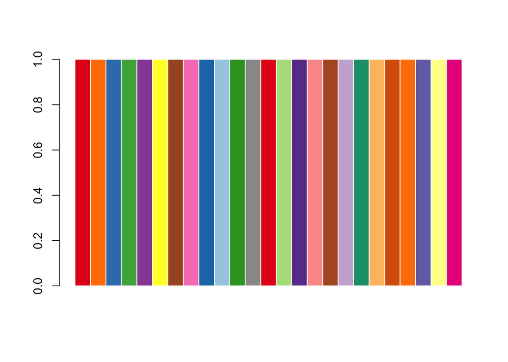

```r
library(RColorBrewer)

# Get the maximum number of colors from three qualitative palettes
set1 <- brewer.pal(brewer.pal.info["Set1", "maxcolors"], "Set1")
set2 <- brewer.pal(brewer.pal.info["Paired", "maxcolors"], "Paired")
set3 <- brewer.pal(brewer.pal.info["Dark2", "maxcolors"], "Dark2")

# Combine them
combined_colors <- c(set1, set2, set3)

# Determine brightness of each color
brightness <- sapply(combined_colors, function(col) {
  grDevices::rgb2hsv(col2rgb(col))["v",]
})

# Classify as 'light' or 'dark'
light_colors <- combined_colors[brightness > median(brightness)]
dark_colors  <- combined_colors[brightness <= median(brightness)]

# Create a function to alternate between two vectors
alternate <- function(a, b) {
  len <- min(length(a), length(b))
  c(rbind(a[1:len], b[1:len]))
}

# Get the first 25 alternating colors
final_colors <- alternate(light_colors, dark_colors)[1:25]

# Function to determine if a color is light or dark
is_light <- function(color) {
  luma <- col2rgb(color)
  luma <- 0.299 * luma[1,] + 0.587 * luma[2,] + 0.114 * luma[3,]
  return(luma > 128)
}


light_colors <- final_colors[sapply(final_colors, is_light)]
dark_colors <- final_colors[!sapply(final_colors, is_light)]

interleave_colors <- function(a, b) {
  len <- min(length(a), length(b))
  result <- vector("character", length(a) + length(b))
  result[seq(1, by=2, length.out=len)] <- a[seq_len(len)]
  result[seq(2, by=2, length.out=len)] <- b[seq_len(len)]
  if(length(a) > len) result[-(1:(2*len))] <- a[-seq_len(len)]
  if(length(b) > len) result[-(1:(2*len))] <- b[-seq_len(len)]
  return(result)
}

pallete1 <- interleave_colors(dark_colors, light_colors)

# Display the colors
barplot(rep(1, 25), col=pallete1, border="white", space=0)
```

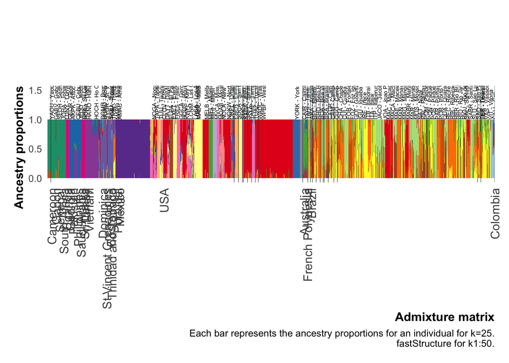

```r
source(
  here(
    "scripts", "analysis", "my_theme3.R"
  )
)


# Melt the data frame for plotting
Q_melted <- k25run2 |>
  pivot_longer(
    cols = -c(ind, pop),
    names_to = "variable",
    values_to = "value"
  )
# Join with sampling_loc to get sampling localities
Q_joined <- Q_melted |>
  left_join(cities, by = c("pop" = "pop"))

# # Create a combined variable for Region and Country
Q_joined <- Q_joined |>
  mutate(Region_Country = interaction(Region, country, sep = "_"))

# Order the combined variable by Region and Country, then by individual
Q_ordered <- Q_joined |>
  arrange(Region, country, city, ind) |>
  mutate(ind = factor(ind, levels = unique(ind)))  # Convert ind to a factor with levels in the desired order

# Add labels: country names for the first individual in each country, NA for all other individuals
Q_ordered <- Q_ordered |>
  group_by(country) |>
  mutate(label = ifelse(row_number() == 1, as.character(country), NA))

# Group by individual and variable, calculate mean ancestry proportions
Q_grouped <- Q_ordered |>
  group_by(ind, variable) |>
  summarise(value = mean(value), .groups = "drop")

# Create a data frame for borders
borders <-
  data.frame(country = unique(Q_ordered$country))

# Add the order of the last individual of each country to ensure correct placement of borders
borders$order <-
  sapply(borders$country, function(rc)
    max(which(Q_ordered$country == rc))) + 0.5  # Shift borders to the right edge of the bars

# Select only the first occurrence of each country in the ordered data
label_df <- Q_ordered |>
  filter(!is.na(label)) |>
  distinct(label, .keep_all = TRUE)

# Create a custom label function
label_func <- function(x) {
  labels <- rep("", length(x))
  labels[x %in% label_df$ind] <- label_df$label
  labels
}

# Calculate the position of lines
border_positions <- Q_ordered |>
  group_by(country) |>
  summarise(pos = max(as.numeric(ind)) + 0)

# Calculate the position of population labels and bars
pop_labels <- Q_ordered |>
  mutate(Name = paste(pop, city, sep = " - ")) |>
  group_by(pop) |>
  slice_head(n = 1) |>
  ungroup() |>
  dplyr::select(ind, city, country, Region, Name) |>
  mutate(pos = as.numeric(ind))  # calculate position of population labels

pop_labels_bars <- pop_labels |>
  mutate(pos = as.numeric(ind)  - 0.5)


# Calculate the position of lines
border_positions <- Q_ordered |>
  group_by(country) |>
  summarise(pos = max(as.numeric(ind)) - 1)


pop_labels_bars <- pop_labels |>
  mutate(pos = as.numeric(ind)  - 0.5)

# Function to filter and normalize data
normalize_data <- function(df, min_value) {
  df |>
    filter(value > min_value) |>
    group_by(ind) |>
    mutate(value = value / sum(value))
}

# Use the function
Q_grouped_filtered <- normalize_data(Q_grouped, 0.05)
#

# Generate all potential variable names
all_variables <- paste0("v", 1:25)


# Create named vector of colors
palette <- setNames(final_colors, all_variables)


# Map each variable to a name
color_mapping <- data.frame(variable = all_variables,
                            color = names(palette))

# Merge with Q_grouped_filtered
Q_grouped_filtered <- merge(Q_grouped_filtered, color_mapping, by = "variable")

# Calculate dominant ancestry for each individual in Q_grouped
dominant_ancestry_df <- Q_grouped %>%
  group_by(ind) %>%
  arrange(desc(value)) %>%
  slice_head(n = 1) %>%
  ungroup() %>%
  dplyr::select(ind, dominant_ancestry = variable, proportion = value)

# Join this dominant ancestry info to Q_ordered
Q_ordered <- Q_ordered %>%
  left_join(dominant_ancestry_df, by = "ind")

# Now, reorder individuals based on region, country, and dominant ancestry
Q_ordered <- Q_ordered %>%
  arrange(Region, country, desc(proportion), ind) %>%
  mutate(ind = factor(ind, levels = unique(ind)))

# Calculate the position of lines
border_positions <- Q_ordered |>
  group_by(country) |>
  summarise(pos = max(as.numeric(ind)) + 0.5)  # Shift borders to the right edge of the bars


# Create the plot
ggplot(Q_grouped_filtered, aes(x = as.factor(ind), y = value, fill = color)) +
  geom_bar(stat = 'identity', width = 1) +
  geom_vline(
    data = border_positions,
    aes(xintercept = pos),
    color = "#2C444A",
    linewidth = .2
  ) +
  geom_text(
    data = pop_labels,
    aes(x = as.numeric(ind), y = 1, label = Name),
    vjust = 1.5,
    hjust = 0,
    size = 2,
    angle = 90,
    inherit.aes = FALSE
  ) +
  my_theme() +
  theme(
    axis.text.x = element_text(
      angle = 90,
      hjust = 1,
      size = 12
    ),
    legend.position = "none",
    plot.margin = unit(c(3, 0.5, 0.5, 0.5), "cm")
  ) +
  xlab("Admixture matrix") +
  ylab("Ancestry proportions") +
  labs(caption = "Each bar represents the ancestry proportions for an individual for k=25.\n fastStructure for k1:50.") +
  scale_x_discrete(labels = label_func) +
  scale_fill_manual(values = palette) +
  expand_limits(y = c(0, 1.5))
```

```r
#   ____________________________________________________________________________
  # save the pca plot                                                       ####
ggsave(
  here(
    "output", "global_brazil", "figures", "fastStructure_k=25_global.pdf"
  ),
  width  = 12,
  height = 7,
  units  = "in",
  device = cairo_pdf
)
```

###### 2.1.9.1.1 Create plot k7

Make plot

```r
# Extract ancestry coefficients
k9run1 <- read_delim(
  here("output", "populations", "faststructure", "luciano", "run01", "simple.7.meanQ"),
  delim = "  ", # Specify the delimiter if different from the default (comma)
  col_names = FALSE,
  show_col_types = FALSE
)

head(k9run1)
```

```
## # A tibble: 6 × 7
##         X1       X2    X3       X4    X5       X6       X7
##      <dbl>    <dbl> <dbl>    <dbl> <dbl>    <dbl>    <dbl>
## 1 0.000009 0.000009 0.396 0.0530   0.551 0.000009 0.000009
## 2 0.000009 0.000009 0.279 0.000009 0.721 0.000009 0.000009
## 3 0.000009 0.518    0.212 0.000009 0.269 0.000009 0.000009
## 4 0.000009 0.000009 0.492 0.000009 0.508 0.000009 0.000009
## 5 0.000009 0.000009 0.320 0.100    0.580 0.000009 0.000009
## 6 0.000009 0.000009 0.228 0.000009 0.772 0.000009 0.000009
```

The fam file

```r
fam_file <- here(
  "output", "populations", "snps_sets", "brazil_2018.fam"
)

# Read the .fam file
fam_data <- read.table(fam_file,
                       header = FALSE,
                       col.names = c("FamilyID", "IndividualID", "PaternalID", "MaternalID", "Sex", "Phenotype"))

# View the first few rows
head(fam_data)
```

```
##   FamilyID IndividualID PaternalID MaternalID Sex Phenotype
## 1      PAR          236          0          0   0        -9
## 2      PAR          237          0          0   0        -9
## 3      PAR          238          0          0   0        -9
## 4      PAR          239          0          0   0        -9
## 5      PAR          240          0          0   0        -9
## 6      PAR          241          0          0   0        -9
```

Create ID column

```r
# Change column name
colnames(fam_data)[colnames(fam_data) == "IndividualID"] <- "ind"


# Change column name
colnames(fam_data)[colnames(fam_data) == "FamilyID"] <- "pop"

# Select ID
fam_data <- fam_data |>
  dplyr::select("ind", "pop")

# View the first few rows
head(fam_data)
```

```
##   ind pop
## 1 236 PAR
## 2 237 PAR
## 3 238 PAR
## 4 239 PAR
## 5 240 PAR
## 6 241 PAR
```

Add it to matrix

```r
k9run1 <- fam_data |>
  dplyr::select(ind, pop) |>
  bind_cols(k9run1)

head(k9run1)
```

```
##   ind pop    X1       X2       X3       X4       X5    X6    X7
## 1 236 PAR 9e-06 0.000009 0.396138 0.052981 0.550847 9e-06 9e-06
## 2 237 PAR 9e-06 0.000009 0.278927 0.000009 0.721028 9e-06 9e-06
## 3 238 PAR 9e-06 0.518217 0.212306 0.000009 0.269442 9e-06 9e-06
## 4 239 PAR 9e-06 0.000009 0.491528 0.000009 0.508428 9e-06 9e-06
## 5 240 PAR 9e-06 0.000009 0.320009 0.099989 0.579967 9e-06 9e-06
## 6 241 PAR 9e-06 0.000009 0.227950 0.000009 0.772006 9e-06 9e-06
```

Rename the columns

```r
# Rename the columns starting from the third one
k9run1 <- k9run1 |>
  rename_with(~paste0("v", seq_along(.x)), .cols = -c(ind, pop))

# View the first few rows
head(k9run1)
```

```
##   ind pop    v1       v2       v3       v4       v5    v6    v7
## 1 236 PAR 9e-06 0.000009 0.396138 0.052981 0.550847 9e-06 9e-06
## 2 237 PAR 9e-06 0.000009 0.278927 0.000009 0.721028 9e-06 9e-06
## 3 238 PAR 9e-06 0.518217 0.212306 0.000009 0.269442 9e-06 9e-06
## 4 239 PAR 9e-06 0.000009 0.491528 0.000009 0.508428 9e-06 9e-06
## 5 240 PAR 9e-06 0.000009 0.320009 0.099989 0.579967 9e-06 9e-06
## 6 241 PAR 9e-06 0.000009 0.227950 0.000009 0.772006 9e-06 9e-06
```

Import sample locations

```r
cities <- readRDS(here("output", "populations", "cities.rds"))
# cities <- cities |>
#   distinct(shortcode, .keep_all = TRUE)

head(cities)
```

```
## # A tibble: 6 × 7
##   pop   city         state latitude longitude region       biome
##   <chr> <chr>        <chr>    <dbl>     <dbl> <chr>        <chr>
## 1 BRA   Brasilia     DF      -15.8      -47.9 Central-West Cerrado
## 2 GOI   Goiania      GO      -16.7      -49.3 Central-West Cerrado
## 3 CAM   Campo Grande MS      -20.4      -54.6 Central-West Pantanal
## 4 CUI   Cuiaba       MT      -15.6      -56.1 Central-West Cerrado
## 5 RBR   Rio Branco   AC       -9.97     -67.8 North        Amazon
## 6 MAN   Manaus       AM       -3.13     -60.0 North        Amazon
```

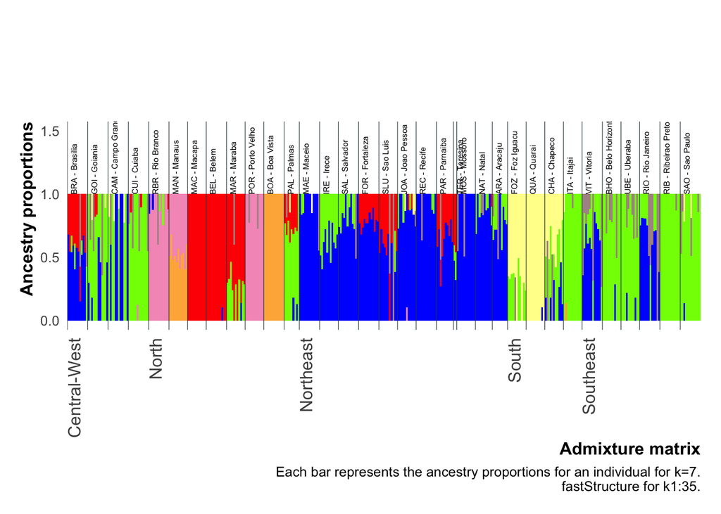

```r
source(
  here(
    "scripts", "analysis", "my_theme3.R"
  )
)

# Melt the data frame for plotting
Q_melted <- k9run1 |>
  pivot_longer(
    cols = -c(ind, pop),
    names_to = "variable",
    values_to = "value"
  )
# Join with sampling_loc to get sampling localities
Q_joined <- Q_melted |>
  left_join(cities, by = c("pop" = "pop"))

# # Create a combined variable for Region and Country
# Q_joined <- Q_joined |>
#   mutate(Region_Country = interaction(Region, Country, sep = "_"))

# Order the combined variable by Region and Country, then by individual
Q_ordered <- Q_joined |>
  arrange(region, state, city, ind) |>
  mutate(ind = factor(ind, levels = unique(ind)))  # Convert ind to a factor with levels in the desired order

# Add labels: country names for the first individual in each country, NA for all other individuals
Q_ordered <- Q_ordered |>
  group_by(region) |>
  mutate(label = ifelse(row_number() == 1, as.character(region), NA))

# Group by individual and variable, calculate mean ancestry proportions
Q_grouped <- Q_ordered |>
  group_by(ind, variable) |>
  summarise(value = mean(value), .groups = "drop")

# Create a data frame for borders
borders <-
  data.frame(region = unique(Q_ordered$region))

# Add the order of the last individual of each country to ensure correct placement of borders
borders$order <-
  sapply(borders$region, function(rc)
    max(which(Q_ordered$region == rc))) + 0.5  # Shift borders to the right edge of the bars

# Select only the first occurrence of each country in the ordered data
label_df <- Q_ordered |>
  filter(!is.na(label)) |>
  distinct(label, .keep_all = TRUE)

# Create a custom label function
label_func <- function(x) {
  labels <- rep("", length(x))
  labels[x %in% label_df$ind] <- label_df$label
  labels
}

# Calculate the position of lines
border_positions <- Q_ordered |>
  group_by(region) |>
  summarise(pos = max(as.numeric(ind)) + 0)

# Calculate the position of population labels and bars
pop_labels <- Q_ordered |>
  mutate(Name = paste(pop, city, sep = " - ")) |>
  group_by(pop) |>
  slice_head(n = 1) |>
  ungroup() |>
  dplyr::select(ind, city, biome, region, Name) |>
  mutate(pos = as.numeric(ind))  # calculate position of population labels

pop_labels_bars <- pop_labels |>
  mutate(pos = as.numeric(ind)  - .5)


# Calculate the position of lines
border_positions <- Q_ordered |>
  group_by(region) |>
  summarise(pos = max(as.numeric(ind)) - 1)


pop_labels_bars <- pop_labels |>
  mutate(pos = as.numeric(ind)  - .5)

# Function to filter and normalize data
normalize_data <- function(df, min_value) {
  df |>
    filter(value > min_value) |>
    group_by(ind) |>
    mutate(value = value / sum(value))
}

# Use the function
Q_grouped_filtered <- normalize_data(Q_grouped, 0.1)
#

color_palette <- c(
  "v1" = "#FFFF99",
  "v2" = "#AE9393",
  "v3" = "red",
  "v4" = "#7FFF00",
  "v5" = "blue",
  "v6" = "#F49AC2",
  "v7" = "#FFB347",
  "v8" = "brown"
)

# Generate all potential variable names
all_variables <- paste0("v", 1:8)

# Map each variable to a name
color_mapping <- data.frame(variable = all_variables,
                            color = names(color_palette))

# Merge with Q_grouped_filtered
Q_grouped_filtered <- merge(Q_grouped_filtered, color_mapping, by = "variable")

# Create the plot
ggplot(Q_grouped_filtered, aes(x = as.factor(ind), y = value, fill = color)) +
  geom_bar(stat = 'identity', width = 1) +
  geom_vline(
    data = pop_labels_bars,
    aes(xintercept = pos),
    color = "#2C444A",
    linewidth = .2
  ) +
  geom_text(
    data = pop_labels,
    aes(x = as.numeric(ind), y = 1, label = Name),
    vjust = 1.5,
    hjust = 0,
    size = 2,
    angle = 90,
    inherit.aes = FALSE
  ) +
  my_theme() +
  theme(
    axis.text.x = element_text(
      angle = 90,
      hjust = 1,
      size = 12
    ),
    legend.position = "none",
    plot.margin = unit(c(3, 0.5, 0.5, 0.5), "cm")
  ) +
  xlab("Admixture matrix") +
  ylab("Ancestry proportions") +
  labs(caption = "Each bar represents the ancestry proportions for an individual for k=7.\n fastStructure for k1:35.") +
  scale_x_discrete(labels = label_func) +
  scale_fill_manual(values = color_palette) +
  expand_limits(y = c(0, 1.5))
```

```r
# # save it
ggsave(
  here("output", "populations", "figures", "faststructure_simple_k7_luciano.pdf"),
  width  = 12,
  height = 6,
  units  = "in",
  device = cairo_pdf
)
```

###### 2.1.9.1.1 Create plot k6

Make plot

```r
# Extract ancestry coefficients
k9run1 <- read_delim(
  here("output", "populations", "faststructure", "luciano", "run01", "simple.6.meanQ"),
  delim = "  ", # Specify the delimiter if different from the default (comma)
  col_names = FALSE,
  show_col_types = FALSE
)

head(k9run1)
```

```
## # A tibble: 6 × 6
##        X1      X2    X3    X4      X5      X6
##     <dbl>   <dbl> <dbl> <dbl>   <dbl>   <dbl>
## 1 0.00001 0.00001 0.551 0.387 0.00001 0.0613
## 2 0.00001 0.00001 0.694 0.260 0.00001 0.0456
## 3 0.00001 0.505   0.304 0.191 0.00001 0.00001
## 4 0.00001 0.00001 0.500 0.500 0.00001 0.00001
## 5 0.00001 0.00001 0.592 0.313 0.00001 0.0947
## 6 0.00001 0.00001 0.768 0.232 0.00001 0.00001
```

The fam file

```r
fam_file <- here(
  "output", "populations", "snps_sets", "brazil_2018.fam"
)

# Read the .fam file
fam_data <- read.table(fam_file,
                       header = FALSE,
                       col.names = c("FamilyID", "IndividualID", "PaternalID", "MaternalID", "Sex", "Phenotype"))

# View the first few rows
head(fam_data)
```

```
##   FamilyID IndividualID PaternalID MaternalID Sex Phenotype
## 1      PAR          236          0          0   0        -9
## 2      PAR          237          0          0   0        -9
## 3      PAR          238          0          0   0        -9
## 4      PAR          239          0          0   0        -9
## 5      PAR          240          0          0   0        -9
## 6      PAR          241          0          0   0        -9
```

Create ID column

```r
# Change column name
colnames(fam_data)[colnames(fam_data) == "IndividualID"] <- "ind"


# Change column name
colnames(fam_data)[colnames(fam_data) == "FamilyID"] <- "pop"

# Select ID
fam_data <- fam_data |>
  dplyr::select("ind", "pop")

# View the first few rows
head(fam_data)
```

```
##   ind pop
## 1 236 PAR
## 2 237 PAR
## 3 238 PAR
## 4 239 PAR
## 5 240 PAR
## 6 241 PAR
```

Add it to matrix

```r
k9run1 <- fam_data |>
  dplyr::select(ind, pop) |>
  bind_cols(k9run1)

head(k9run1)
```

```
##   ind pop    X1       X2       X3       X4    X5       X6
## 1 236 PAR 1e-05 0.000010 0.551402 0.387283 1e-05 0.061284
## 2 237 PAR 1e-05 0.000010 0.693990 0.260356 1e-05 0.045623
## 3 238 PAR 1e-05 0.504988 0.303642 0.191339 1e-05 0.000010
## 4 239 PAR 1e-05 0.000010 0.499967 0.499992 1e-05 0.000010
## 5 240 PAR 1e-05 0.000010 0.592426 0.312867 1e-05 0.094676
## 6 241 PAR 1e-05 0.000010 0.767546 0.232413 1e-05 0.000010
```

Rename the columns

```r
# Rename the columns starting from the third one
k9run1 <- k9run1 |>
  rename_with(~paste0("v", seq_along(.x)), .cols = -c(ind, pop))

# View the first few rows
head(k9run1)
```

```
##   ind pop    v1       v2       v3       v4    v5       v6
## 1 236 PAR 1e-05 0.000010 0.551402 0.387283 1e-05 0.061284
## 2 237 PAR 1e-05 0.000010 0.693990 0.260356 1e-05 0.045623
## 3 238 PAR 1e-05 0.504988 0.303642 0.191339 1e-05 0.000010
## 4 239 PAR 1e-05 0.000010 0.499967 0.499992 1e-05 0.000010
## 5 240 PAR 1e-05 0.000010 0.592426 0.312867 1e-05 0.094676
## 6 241 PAR 1e-05 0.000010 0.767546 0.232413 1e-05 0.000010
```

Import sample locations

```r
cities <- readRDS(here("output", "populations", "cities.rds"))
# cities <- cities |>
#   distinct(shortcode, .keep_all = TRUE)

head(cities)
```

```
## # A tibble: 6 × 7
##   pop   city         state latitude longitude region       biome
##   <chr> <chr>        <chr>    <dbl>     <dbl> <chr>        <chr>
## 1 BRA   Brasilia     DF      -15.8      -47.9 Central-West Cerrado
## 2 GOI   Goiania      GO      -16.7      -49.3 Central-West Cerrado
## 3 CAM   Campo Grande MS      -20.4      -54.6 Central-West Pantanal
## 4 CUI   Cuiaba       MT      -15.6      -56.1 Central-West Cerrado
## 5 RBR   Rio Branco   AC       -9.97     -67.8 North        Amazon
## 6 MAN   Manaus       AM       -3.13     -60.0 North        Amazon
```

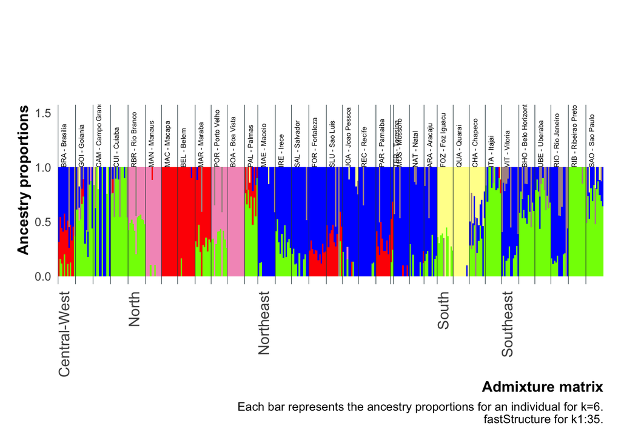

```r
source(
  here(
    "scripts", "analysis", "my_theme3.R"
  )
)

# Melt the data frame for plotting
Q_melted <- k9run1 |>
  pivot_longer(
    cols = -c(ind, pop),
    names_to = "variable",
    values_to = "value"
  )
# Join with sampling_loc to get sampling localities
Q_joined <- Q_melted |>
  left_join(cities, by = c("pop" = "pop"))

# # Create a combined variable for Region and Country
# Q_joined <- Q_joined |>
#   mutate(Region_Country = interaction(Region, Country, sep = "_"))

# Order the combined variable by Region and Country, then by individual
Q_ordered <- Q_joined |>
  arrange(region, state, city, ind) |>
  mutate(ind = factor(ind, levels = unique(ind)))  # Convert ind to a factor with levels in the desired order

# Add labels: country names for the first individual in each country, NA for all other individuals
Q_ordered <- Q_ordered |>
  group_by(region) |>
  mutate(label = ifelse(row_number() == 1, as.character(region), NA))

# Group by individual and variable, calculate mean ancestry proportions
Q_grouped <- Q_ordered |>
  group_by(ind, variable) |>
  summarise(value = mean(value), .groups = "drop")

# Create a data frame for borders
borders <-
  data.frame(region = unique(Q_ordered$region))

# Add the order of the last individual of each country to ensure correct placement of borders
borders$order <-
  sapply(borders$region, function(rc)
    max(which(Q_ordered$region == rc))) + 0.5  # Shift borders to the right edge of the bars

# Select only the first occurrence of each country in the ordered data
label_df <- Q_ordered |>
  filter(!is.na(label)) |>
  distinct(label, .keep_all = TRUE)

# Create a custom label function
label_func <- function(x) {
  labels <- rep("", length(x))
  labels[x %in% label_df$ind] <- label_df$label
  labels
}

# Calculate the position of lines
border_positions <- Q_ordered |>
  group_by(region) |>
  summarise(pos = max(as.numeric(ind)) + 0)

# Calculate the position of population labels and bars
pop_labels <- Q_ordered |>
  mutate(Name = paste(pop, city, sep = " - ")) |>
  group_by(pop) |>
  slice_head(n = 1) |>
  ungroup() |>
  dplyr::select(ind, city, biome, region, Name) |>
  mutate(pos = as.numeric(ind))  # calculate position of population labels

pop_labels_bars <- pop_labels |>
  mutate(pos = as.numeric(ind)  - .5)


# Calculate the position of lines
border_positions <- Q_ordered |>
  group_by(region) |>
  summarise(pos = max(as.numeric(ind)) - 1)


pop_labels_bars <- pop_labels |>
  mutate(pos = as.numeric(ind)  - .5)

# Function to filter and normalize data
normalize_data <- function(df, min_value) {
  df |>
    filter(value > min_value) |>
    group_by(ind) |>
    mutate(value = value / sum(value))
}

# Use the function
Q_grouped_filtered <- normalize_data(Q_grouped, 0.1)
#

color_palette <- c(
  "v1" = "#FFFF99",
  "v2" = "#AE9393",
  "v3" = "blue",
  "v4" = "red",
  "v5" = "#F49AC2",
  "v6" = "#7FFF00",
  "v7" = "#FFB347",
  "v8" = "brown"
)

# Generate all potential variable names
all_variables <- paste0("v", 1:8)

# Map each variable to a name
color_mapping <- data.frame(variable = all_variables,
                            color = names(color_palette))

# Merge with Q_grouped_filtered
Q_grouped_filtered <- merge(Q_grouped_filtered, color_mapping, by = "variable")

# Create the plot
ggplot(Q_grouped_filtered, aes(x = as.factor(ind), y = value, fill = color)) +
  geom_bar(stat = 'identity', width = 1) +
  geom_vline(
    data = pop_labels_bars,
    aes(xintercept = pos),
    color = "#2C444A",
    linewidth = .2
  ) +
  geom_text(
    data = pop_labels,
    aes(x = as.numeric(ind), y = 1, label = Name),
    vjust = 1.5,
    hjust = 0,
    size = 2,
    angle = 90,
    inherit.aes = FALSE
  ) +
  my_theme() +
  theme(
    axis.text.x = element_text(
      angle = 90,
      hjust = 1,
      size = 12
    ),
    legend.position = "none",
    plot.margin = unit(c(3, 0.5, 0.5, 0.5), "cm")
  ) +
  xlab("Admixture matrix") +
  ylab("Ancestry proportions") +
  labs(caption = "Each bar represents the ancestry proportions for an individual for k=6.\n fastStructure for k1:35.") +
  scale_x_discrete(labels = label_func) +
  scale_fill_manual(values = color_palette) +
  expand_limits(y = c(0, 1.5))
```

```r
# # save it
ggsave(
  here("output", "populations", "figures", "faststructure_simple_k6_luciano.pdf"),
  width  = 12,
  height = 6,
  units  = "in",
  device = cairo_pdf
)
```

###### 2.1.9.1.1 Create plot k5

Make plot

```r
# Extract ancestry coefficients
k9run1 <- read_delim(
  here("output", "populations", "faststructure", "luciano", "run01", "simple.5.meanQ"),
  delim = "  ", # Specify the delimiter if different from the default (comma)
  col_names = FALSE,
  show_col_types = FALSE
)

head(k9run1)
```

```
## # A tibble: 6 × 5
##         X1       X2    X3       X4    X5
##      <dbl>    <dbl> <dbl>    <dbl> <dbl>
## 1 0.0048   0.000012 0.559 0.000012 0.436
## 2 0.000013 0.000013 0.690 0.000013 0.310
## 3 0.445    0.000013 0.393 0.000013 0.162
## 4 0.000013 0.000013 0.485 0.000013 0.515
## 5 0.000013 0.000013 0.618 0.000013 0.382
## 6 0.000013 0.000013 0.744 0.000013 0.256
```

The fam file

```r
fam_file <- here(
  "output", "populations", "snps_sets", "brazil_2018.fam"
)

# Read the .fam file
fam_data <- read.table(fam_file,
                       header = FALSE,
                       col.names = c("FamilyID", "IndividualID", "PaternalID", "MaternalID", "Sex", "Phenotype"))

# View the first few rows
head(fam_data)
```

```
##   FamilyID IndividualID PaternalID MaternalID Sex Phenotype
## 1      PAR          236          0          0   0        -9
## 2      PAR          237          0          0   0        -9
## 3      PAR          238          0          0   0        -9
## 4      PAR          239          0          0   0        -9
## 5      PAR          240          0          0   0        -9
## 6      PAR          241          0          0   0        -9
```

Create ID column

```r
# Change column name
colnames(fam_data)[colnames(fam_data) == "IndividualID"] <- "ind"


# Change column name
colnames(fam_data)[colnames(fam_data) == "FamilyID"] <- "pop"

# Select ID
fam_data <- fam_data |>
  dplyr::select("ind", "pop")

# View the first few rows
head(fam_data)
```

```
##   ind pop
## 1 236 PAR
## 2 237 PAR
## 3 238 PAR
## 4 239 PAR
## 5 240 PAR
## 6 241 PAR
```

Add it to matrix

```r
k9run1 <- fam_data |>
  dplyr::select(ind, pop) |>
  bind_cols(k9run1)

head(k9run1)
```

```
##   ind pop       X1      X2       X3      X4       X5
## 1 236 PAR 0.004800 1.2e-05 0.559241 1.2e-05 0.435934
## 2 237 PAR 0.000013 1.3e-05 0.690291 1.3e-05 0.309671
## 3 238 PAR 0.444752 1.3e-05 0.393238 1.3e-05 0.161985
## 4 239 PAR 0.000013 1.3e-05 0.485091 1.3e-05 0.514871
## 5 240 PAR 0.000013 1.3e-05 0.617889 1.3e-05 0.382073
## 6 241 PAR 0.000013 1.3e-05 0.743788 1.3e-05 0.256174
```

Rename the columns

```r
# Rename the columns starting from the third one
k9run1 <- k9run1 |>
  rename_with(~paste0("v", seq_along(.x)), .cols = -c(ind, pop))

# View the first few rows
head(k9run1)
```

```
##   ind pop       v1      v2       v3      v4       v5
## 1 236 PAR 0.004800 1.2e-05 0.559241 1.2e-05 0.435934
## 2 237 PAR 0.000013 1.3e-05 0.690291 1.3e-05 0.309671
## 3 238 PAR 0.444752 1.3e-05 0.393238 1.3e-05 0.161985
## 4 239 PAR 0.000013 1.3e-05 0.485091 1.3e-05 0.514871
## 5 240 PAR 0.000013 1.3e-05 0.617889 1.3e-05 0.382073
## 6 241 PAR 0.000013 1.3e-05 0.743788 1.3e-05 0.256174
```

Import sample locations

```r
cities <- readRDS(here("output", "populations", "cities.rds"))
# cities <- cities |>
#   distinct(shortcode, .keep_all = TRUE)

head(cities)
```

```
## # A tibble: 6 × 7
##   pop   city         state latitude longitude region       biome
##   <chr> <chr>        <chr>    <dbl>     <dbl> <chr>        <chr>
## 1 BRA   Brasilia     DF      -15.8      -47.9 Central-West Cerrado
## 2 GOI   Goiania      GO      -16.7      -49.3 Central-West Cerrado
## 3 CAM   Campo Grande MS      -20.4      -54.6 Central-West Pantanal
## 4 CUI   Cuiaba       MT      -15.6      -56.1 Central-West Cerrado
## 5 RBR   Rio Branco   AC       -9.97     -67.8 North        Amazon
## 6 MAN   Manaus       AM       -3.13     -60.0 North        Amazon
```

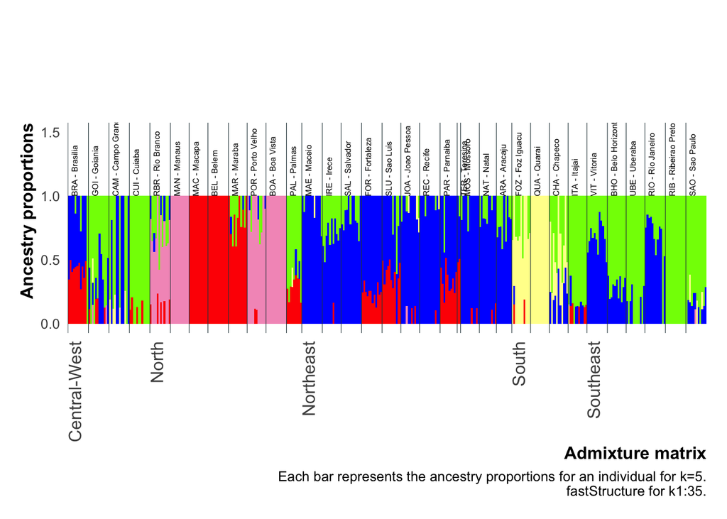

```r
source(
  here(
    "scripts", "analysis", "my_theme3.R"
  )
)

# Melt the data frame for plotting
Q_melted <- k9run1 |>
  pivot_longer(
    cols = -c(ind, pop),
    names_to = "variable",
    values_to = "value"
  )
# Join with sampling_loc to get sampling localities
Q_joined <- Q_melted |>
  left_join(cities, by = c("pop" = "pop"))

# # Create a combined variable for Region and Country
# Q_joined <- Q_joined |>
#   mutate(Region_Country = interaction(Region, Country, sep = "_"))

# Order the combined variable by Region and Country, then by individual
Q_ordered <- Q_joined |>
  arrange(region, state, city, ind) |>
  mutate(ind = factor(ind, levels = unique(ind)))  # Convert ind to a factor with levels in the desired order

# Add labels: country names for the first individual in each country, NA for all other individuals
Q_ordered <- Q_ordered |>
  group_by(region) |>
  mutate(label = ifelse(row_number() == 1, as.character(region), NA))

# Group by individual and variable, calculate mean ancestry proportions
Q_grouped <- Q_ordered |>
  group_by(ind, variable) |>
  summarise(value = mean(value), .groups = "drop")

# Create a data frame for borders
borders <-
  data.frame(region = unique(Q_ordered$region))

# Add the order of the last individual of each country to ensure correct placement of borders
borders$order <-
  sapply(borders$region, function(rc)
    max(which(Q_ordered$region == rc))) + 0.5  # Shift borders to the right edge of the bars

# Select only the first occurrence of each country in the ordered data
label_df <- Q_ordered |>
  filter(!is.na(label)) |>
  distinct(label, .keep_all = TRUE)

# Create a custom label function
label_func <- function(x) {
  labels <- rep("", length(x))
  labels[x %in% label_df$ind] <- label_df$label
  labels
}

# Calculate the position of lines
border_positions <- Q_ordered |>
  group_by(region) |>
  summarise(pos = max(as.numeric(ind)) + 0)

# Calculate the position of population labels and bars
pop_labels <- Q_ordered |>
  mutate(Name = paste(pop, city, sep = " - ")) |>
  group_by(pop) |>
  slice_head(n = 1) |>
  ungroup() |>
  dplyr::select(ind, city, biome, region, Name) |>
  mutate(pos = as.numeric(ind))  # calculate position of population labels

pop_labels_bars <- pop_labels |>
  mutate(pos = as.numeric(ind)  - .5)


# Calculate the position of lines
border_positions <- Q_ordered |>
  group_by(region) |>
  summarise(pos = max(as.numeric(ind)) - 1)


pop_labels_bars <- pop_labels |>
  mutate(pos = as.numeric(ind)  - .5)

# Function to filter and normalize data
normalize_data <- function(df, min_value) {
  df |>
    filter(value > min_value) |>
    group_by(ind) |>
    mutate(value = value / sum(value))
}

# Use the function
Q_grouped_filtered <- normalize_data(Q_grouped, 0.1)
#

color_palette <- c(
  "v1" = "#7FFF00",
  "v2" = "#FFFF99",
  "v3" = "blue",
  "v4" = "#F49AC2",
  "v5" = "red",
  "v6" = "#AE9393",
  "v7" = "#FFB347",
  "v8" = "brown"
)

# Generate all potential variable names
all_variables <- paste0("v", 1:8)

# Map each variable to a name
color_mapping <- data.frame(variable = all_variables,
                            color = names(color_palette))

# Merge with Q_grouped_filtered
Q_grouped_filtered <- merge(Q_grouped_filtered, color_mapping, by = "variable")

# Create the plot
ggplot(Q_grouped_filtered, aes(x = as.factor(ind), y = value, fill = color)) +
  geom_bar(stat = 'identity', width = 1) +
  geom_vline(
    data = pop_labels_bars,
    aes(xintercept = pos),
    color = "#2C444A",
    linewidth = .2
  ) +
  geom_text(
    data = pop_labels,
    aes(x = as.numeric(ind), y = 1, label = Name),
    vjust = 1.5,
    hjust = 0,
    size = 2,
    angle = 90,
    inherit.aes = FALSE
  ) +
  my_theme() +
  theme(
    axis.text.x = element_text(
      angle = 90,
      hjust = 1,
      size = 12
    ),
    legend.position = "none",
    plot.margin = unit(c(3, 0.5, 0.5, 0.5), "cm")
  ) +
  xlab("Admixture matrix") +
  ylab("Ancestry proportions") +
  labs(caption = "Each bar represents the ancestry proportions for an individual for k=5.\n fastStructure for k1:35.") +
  scale_x_discrete(labels = label_func) +
  scale_fill_manual(values = color_palette) +
  expand_limits(y = c(0, 1.5))
```

```r
# # save it
ggsave(
  here("output", "populations", "figures", "faststructure_simple_k5_luciano.pdf"),
  width  = 12,
  height = 6,
  units  = "in",
  device = cairo_pdf
)
```